# titanic-exploratory-data-analysis

shobha mourya

March 4, 2019

# 1 Exploratory Data Analysis

**Analysis of Titanic Passenger Surival**

Using Titanic dataset

**Using dplyr R package**

- for data wrangling and feature engineering
- dplyr makes you much more productive and far more intuitive
- Look at the help resources ?dplyr
- dplyr: a grammar of data manipulation collection of functions that makes working with data

## 1.1 Why do feature engineering?

In most Data Science scenarios, Feature Engineering is paramount

- Feature engineering often trumps algorithms, more data, parameter tuning, etc.

Data Scientist spend 60-80% of their time on being data janitors

- getting data, understanding data, cleaning data, feature engineering commonly referred to as data wrangling

Faster data wrangling == more business value!

- if you can do data wrangling faster - you can compete much much more effective

*To win Kaggle - feature engineering is most important*

In business textual data is more than numeric data categorical data is more common categorical data - think of dropdown with US states discrete variables It is important to learn to work with string data

## 1.2 Types of Joins

### 1.2.1 left_join

- all rows of primary table and matching rows of right

### 1.2.2 right_join

- all rows of secondary table and only matching rows of primary table

### 1.2.3 inner_join

- only match rows from primary and secondary tables

### 1.2.4 full_join

- all rows from both tables and matching rows

### 1.2.5 semi_join

- rows & columns only from primary table that have matching in secondary table
- no data from second table is shown

### 1.2.6 anti-join

- rows & columns from primary table that don’t have matches in second table

## 1.3 What is Imputation?

- It is data cleansing step of data analysis in which we deduce the missing (NA) values
- or values that are incorrect based on the domain knowledge of the case study.

For example, in the Titanic Passenger Survival dataset, there are many observations with missing ‘Age’ values and there are observations where ‘Fare’ is zero. After analysing we use generalization to assign the mean/median value based on the similarity of the missing data point wrt to other data points.

## 1.4 Steps for Imputing missing values

We mostly followed the below step in our imputation process:

### 1.4.1 Stats subset

To understand the distribution of the feature we want to impute we create a subset of statistical measures like min, max, mean, median, IQR, variance(var), standard deviation (sd), sum/count etc.

### 1.4.2 Analyse stats

In this step, we view the statistics subset to analyse what would be the best value to assign, mean or median, for imputation. If the feature distribution is not skewed, that is there is not much variation between the min/max, we can use the mean for the missing values. However, if the distribution has extreme values we can use median. Note. Mean is a computed value affected by min and max hence in case of skewed data median is a better generalisation than mean for missing values.

### 1.4.3 Indicator variable

We create an indicator variable with values Y (for yes) and N (for no) to serve as a flag to indicate if the observation has imputed values for a specific variable. For example, variable ‘AgeMissing’ indicates whether age is imputed or not. This helps in reverse engineer if at all we need to the original value in later stages of analysis or while building the prediction model.

### 1.4.4 Lookup table

After we have decided on what statistics/values to use for imputation we create a lookup table with the new values and the common feature by which we will join the lookup table with the original table. If we’re dealing with GroupWise imputation you might have to consider adding the group column and the common columns. For example, ‘Fare’ depends on the passenger class - price of first class is bound to be more than other classes and hence mean of the first class will be different than the mean of other classes.

### 1.4.5 Left Join the lookup subset

Join the original dataset with the lookup subset using the appropriate join columns. This step adds the new columns to the original dataset - you can crosscheck using the names command.

### 1.4.6 Impute the values

Use the mutate dplyr command to assign the new values to the feature being imputed based on the appropriate conditions. For example, use the indicator flag and then apply the condition.

### 1.4.7 Crosscheck

It is important to cross check that all the imputations have been applied correctly. Use summary command on the imputed feature to see if there are any NAs or wrong values. If there are errors, then revisit the code and check the conditions in mutate command.

### 1.4.8 Remove the additional columns

After assigning the appropriate statistic/value to the missing values using lookup table column values, their purpose is served and they should be removed from the original dataset. Use select(-column) or set the column to NULL to remove the columns.

# 2 Analyse train dataset

Load the packages

```r
#install.packages("dplyr")
#install.packages("ggplot2")
#install.packages("stringr")

library(dplyr)
library(ggplot2)
library(stringr)
# Load raw data
path = "C:/Users/shobha/Documents/RExploratyDataAnalysis"
train = read.csv(paste0(path,"/dataFiles/train.csv"), header=TRUE)

dim(train)
```

```
## [1] 891  11
```

```r
str(train)
```

```
## 'data.frame':    891 obs. of  11 variables:
##  $ survived: int  0 1 1 1 0 0 0 0 1 1 ...
##  $ pclass  : int  3 1 3 1 3 3 1 3 3 2 ...
##  $ name    : Factor w/ 891 levels "Abbing, Mr. Anthony",..: 109 191 358 277 16 559 520 629 417 581 ...
##  $ sex     : Factor w/ 2 levels "female","male": 2 1 1 1 2 2 2 2 1 1 ...
##  $ age     : num  22 38 26 35 35 NA 54 2 27 14 ...
##  $ sibsp   : int  1 1 0 1 0 0 0 3 0 1 ...
##  $ parch   : int  0 0 0 0 0 0 0 1 2 0 ...
##  $ ticket  : Factor w/ 681 levels "110152","110413",..: 524 597 670 50 473 276 86 396 345 133 ...
##  $ fare    : num  7.25 71.28 7.92 53.1 8.05 ...
##  $ cabin   : Factor w/ 148 levels "","A10","A14",..: 1 83 1 57 1 1 131 1 1 1 ...
##  $ embarked: Factor w/ 4 levels "","C","Q","S": 4 2 4 4 4 3 4 4 4 2 ...
```

```r
glimpse(train)
```

```
## Observations: 891
## Variables: 11
## $ survived <int> 0, 1, 1, 1, 0, 0, 0, 0, 1, 1, 1, 1, 0, 0, 0, 1, 0, 1,...
## $ pclass   <int> 3, 1, 3, 1, 3, 3, 1, 3, 3, 2, 3, 1, 3, 3, 3, 2, 3, 2,...
## $ name     <fct> "Braund, Mr. Owen Harris", "Cumings, Mrs. John Bradle...
## $ sex      <fct> male, female, female, female, male, male, male, male,...
## $ age      <dbl> 22, 38, 26, 35, 35, NA, 54, 2, 27, 14, 4, 58, 20, 39,...
## $ sibsp    <int> 1, 1, 0, 1, 0, 0, 0, 3, 0, 1, 1, 0, 0, 1, 0, 0, 4, 0,...
## $ parch    <int> 0, 0, 0, 0, 0, 0, 0, 1, 2, 0, 1, 0, 0, 5, 0, 0, 1, 0,...
## $ ticket   <fct> A/5 21171, PC 17599, STON/O2. 3101282, 113803, 373450...
## $ fare     <dbl> 7.2500, 71.2833, 7.9250, 53.1000, 8.0500, 8.4583, 51....
## $ cabin    <fct> , C85, , C123, , , E46, , , , G6, C103, , , , , , , ,...
## $ embarked <fct> S, C, S, S, S, Q, S, S, S, C, S, S, S, S, S, S, Q, S,...
```

```r
names(train)
```

```
##  [1] "survived" "pclass"   "name"     "sex"      "age"      "sibsp"
##  [7] "parch"    "ticket"   "fare"     "cabin"    "embarked"
```

```r
#View(train)
```

## 2.1 Variables

### 2.1.2 Survived

It is our label It is the dependent variable we are trying to predict Other variables are predictors - we need to feature engineer on predictors

### 2.1.3 Name

It is string variable - scope for feature engineer

### 2.1.4 Sex and Age

Are imp if women and children first is to be true

### 2.1.5 Sibsp

Sibling and Spouse could mean travelling with spouse or sibling

### 2.1.6 Parch

Parent child could mean traveling with parent or child

# 3 Analyse test dataset

```r
test = read.csv(paste0(path,"/dataFiles/test.csv"), header=TRUE)
dim(test)
```

```
## [1] 418  10
```

It has one less column

```r
names(test)
```

```
##  [1] "pclass"   "name"     "sex"      "age"      "sibsp"    "parch"
##  [7] "ticket"   "fare"     "cabin"    "embarked"
```

survived column is removed because we have to predict the survived label with our model

In order to increase our dataset we will comibine the test and train datasets. First lets add the column Survived with None value for test dataset

```r
test.survived = test %>% mutate(survived = "None")
dim(test.survived)
```

```
## [1] 418  11
```

```r
names(test.survived)
```

```
##  [1] "pclass"   "name"     "sex"      "age"      "sibsp"    "parch"
##  [7] "ticket"   "fare"     "cabin"    "embarked" "survived"
```

```r
test.survived$survived = as.factor(test.survived$survived)
train$survived = as.factor(train$survived)

str(test.survived)
```

```
## 'data.frame':    418 obs. of  11 variables:
##  $ pclass  : int  3 3 2 3 3 3 3 2 3 3 ...
##  $ name    : Factor w/ 418 levels "Abbott, Master. Eugene Joseph",..: 210 409 273 414 182 370 85 58 5 104 ...
##  $ sex     : Factor w/ 2 levels "female","male": 2 1 2 2 1 2 1 2 1 2 ...
##  $ age     : num  34.5 47 62 27 22 14 30 26 18 21 ...
##  $ sibsp   : int  0 1 0 0 1 0 0 1 0 2 ...
##  $ parch   : int  0 0 0 0 1 0 0 1 0 0 ...
##  $ ticket  : Factor w/ 363 levels "110469","110489",..: 153 222 74 148 139 262 159 85 101 270 ...
##  $ fare    : num  7.83 7 9.69 8.66 12.29 ...
##  $ cabin   : Factor w/ 77 levels "","A11","A18",..: 1 1 1 1 1 1 1 1 1 1 ...
##  $ embarked: Factor w/ 3 levels "C","Q","S": 2 3 2 3 3 3 2 3 1 3 ...
##  $ survived: Factor w/ 1 level "None": 1 1 1 1 1 1 1 1 1 1 ...
```

```r
str(train)
```

```
## 'data.frame':    891 obs. of  11 variables:
##  $ survived: Factor w/ 2 levels "0","1": 1 2 2 2 1 1 1 1 2 2 ...
##  $ pclass  : int  3 1 3 1 3 3 1 3 3 2 ...
##  $ name    : Factor w/ 891 levels "Abbing, Mr. Anthony",..: 109 191 358 277 16 559 520 629 417 581 ...
##  $ sex     : Factor w/ 2 levels "female","male": 2 1 1 1 2 2 2 2 1 1 ...
##  $ age     : num  22 38 26 35 35 NA 54 2 27 14 ...
##  $ sibsp   : int  1 1 0 1 0 0 0 3 0 1 ...
##  $ parch   : int  0 0 0 0 0 0 0 1 2 0 ...
##  $ ticket  : Factor w/ 681 levels "110152","110413",..: 524 597 670 50 473 276 86 396 345 133 ...
##  $ fare    : num  7.25 71.28 7.92 53.1 8.05 ...
##  $ cabin   : Factor w/ 148 levels "","A10","A14",..: 1 83 1 57 1 1 131 1 1 1 ...
##  $ embarked: Factor w/ 4 levels "","C","Q","S": 4 2 4 4 4 3 4 4 4 2 ...
```

```r
# you can also use rbind
data.combined = train %>% union_all(test.survived)
# data.combined = rbind(train, test.survived)
# dim(data.combined)
# str(data.combined)

dim(data.combined)
```

```
## [1] 1309   11
```

891 + 418 = 1309

Let’s start with data exploration. We will analyse the features one by one to see if they have any predictive power.

# 4 Combine the train and test datasets

We will use this dataset for comparing operations without dplyr

```r
glimpse(data.combined)
```

```
## Observations: 1,309
## Variables: 11
## $ survived <chr> "0", "1", "1", "1", "0", "0", "0", "0", "1", "1", "1"...
## $ pclass   <int> 3, 1, 3, 1, 3, 3, 1, 3, 3, 2, 3, 1, 3, 3, 3, 2, 3, 2,...
## $ name     <chr> "Braund, Mr. Owen Harris", "Cumings, Mrs. John Bradle...
## $ sex      <fct> male, female, female, female, male, male, male, male,...
## $ age      <dbl> 22, 38, 26, 35, 35, NA, 54, 2, 27, 14, 4, 58, 20, 39,...
## $ sibsp    <int> 1, 1, 0, 1, 0, 0, 0, 3, 0, 1, 1, 0, 0, 1, 0, 0, 4, 0,...
## $ parch    <int> 0, 0, 0, 0, 0, 0, 0, 1, 2, 0, 1, 0, 0, 5, 0, 0, 1, 0,...
## $ ticket   <chr> "A/5 21171", "PC 17599", "STON/O2. 3101282", "113803"...
## $ fare     <dbl> 7.2500, 71.2833, 7.9250, 53.1000, 8.0500, 8.4583, 51....
## $ cabin    <chr> "", "C85", "", "C123", "", "", "E46", "", "", "", "G6...
## $ embarked <chr> "S", "C", "S", "S", "S", "Q", "S", "S", "S", "C", "S"...
```

```r
# convert survived, pclass to factor
data.combined$survived = as.factor(data.combined$survived)
data.combined$pclass = as.factor(data.combined$pclass)

glimpse(data.combined)
```

```
## Observations: 1,309
## Variables: 11
## $ survived <fct> 0, 1, 1, 1, 0, 0, 0, 0, 1, 1, 1, 1, 0, 0, 0, 1, 0, 1,...
## $ pclass   <fct> 3, 1, 3, 1, 3, 3, 1, 3, 3, 2, 3, 1, 3, 3, 3, 2, 3, 2,...
## $ name     <chr> "Braund, Mr. Owen Harris", "Cumings, Mrs. John Bradle...
## $ sex      <fct> male, female, female, female, male, male, male, male,...
## $ age      <dbl> 22, 38, 26, 35, 35, NA, 54, 2, 27, 14, 4, 58, 20, 39,...
## $ sibsp    <int> 1, 1, 0, 1, 0, 0, 0, 3, 0, 1, 1, 0, 0, 1, 0, 0, 4, 0,...
## $ parch    <int> 0, 0, 0, 0, 0, 0, 0, 1, 2, 0, 1, 0, 0, 5, 0, 0, 1, 0,...
## $ ticket   <chr> "A/5 21171", "PC 17599", "STON/O2. 3101282", "113803"...
## $ fare     <dbl> 7.2500, 71.2833, 7.9250, 53.1000, 8.0500, 8.4583, 51....
## $ cabin    <chr> "", "C85", "", "C123", "", "", "E46", "", "", "", "G6...
## $ embarked <chr> "S", "C", "S", "S", "S", "Q", "S", "S", "S", "C", "S"...
```

```r
# Let's see the distribution of survival rates
table(data.combined$survived)
```

```
##
##    0    1 None
##  549  342  418
```

```r
names(data.combined)
```

```
##  [1] "survived" "pclass"   "name"     "sex"      "age"      "sibsp"
##  [7] "parch"    "ticket"   "fare"     "cabin"    "embarked"
```

# 5 Analyse the variables for their predictive power

## 5.1 Explore pclass feature

```r
# Distribution of passengers across classes
table(data.combined$pclass)
```

```
##
##   1   2   3
## 323 277 709
```

```r
round(prop.table(table(data.combined$pclass))*100)
```

```
##
##  1  2  3
## 25 21 54
```

More than 50% passengers traveled in third class. Our Hypothesis is that rich folks, traveling in first class, survived at a higher rate

Let’s visualize pclass distribution wrt to survival for train dataset

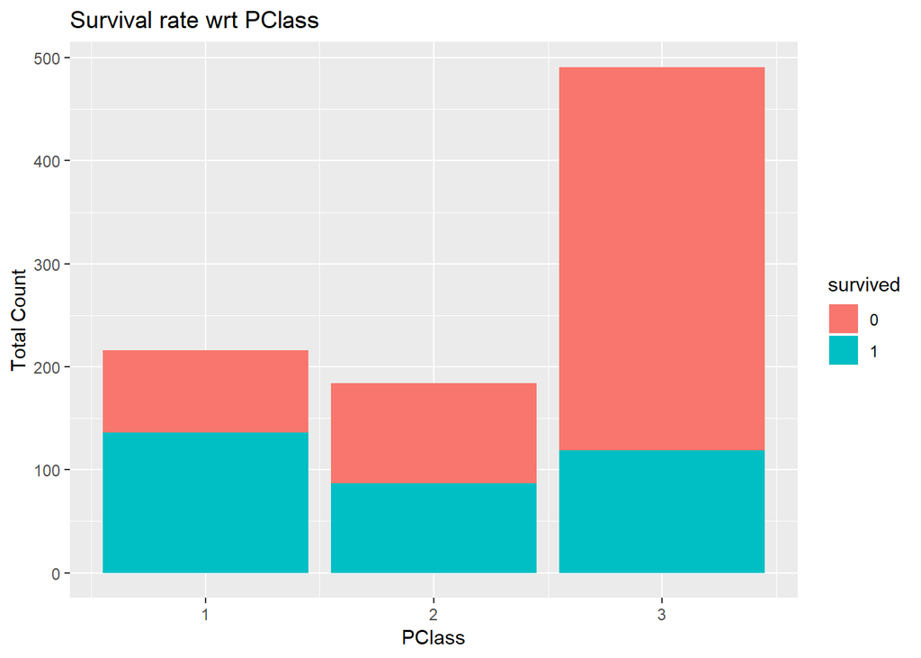

```r
ggplot(train, aes(x = pclass, fill=survived)) +
  geom_bar() +
  xlab("PClass") +
  ylab("Total Count") +
  ggtitle("Survival rate wrt PClass")
```

### 5.1.1 Interprete

The visualization shows that proportion of perished is higher in second and third class as compared to first class. So pclass seems to have good predictive power.

## 5.2 Explore name feature

Now, let’s examine the name feature

Examine the first few names in the training data set

The names have lastname, title. firstname middlename (maiden name)

```r
head(as.character(train$name))
```

```
## [1] "Braund, Mr. Owen Harris"
## [2] "Cumings, Mrs. John Bradley (Florence Briggs Thayer)"
## [3] "Heikkinen, Miss. Laina"
## [4] "Futrelle, Mrs. Jacques Heath (Lily May Peel)"
## [5] "Allen, Mr. William Henry"
## [6] "Moran, Mr. James"
```

```r
tail(as.character(train$name))
```

```
## [1] "Rice, Mrs. William (Margaret Norton)"
## [2] "Montvila, Rev. Juozas"
## [3] "Graham, Miss. Margaret Edith"
## [4] "Johnston, Miss. Catherine Helen \"Carrie\""
## [5] "Behr, Mr. Karl Howell"
## [6] "Dooley, Mr. Patrick"
```

```r
#View(head(data.combined, 20))

# How many unique names are there across both train & test?
length(unique(as.character(data.combined$name)))
```

```
## [1] 1307
```

```r
length(data.combined$name)
```

```
## [1] 1309
```

1307 out of 1309, so there are two duplicate names.

```r
dup.names = data.combined[(duplicated(data.combined$name) == TRUE),]

dup.names
```

```
##     survived pclass                 name    sex  age sibsp parch ticket
## 892     None      3     Kelly, Mr. James   male 34.5     0     0 330911
## 898     None      3 Connolly, Miss. Kate female 30.0     0     0 330972
##       fare cabin embarked
## 892 7.8292              Q
## 898 7.6292              Q
```

### 5.2.1 Create new feature title from name

Let’s create a new feature title from the name variable by extracting the pattern which has characters followed by .

Regex - starts with char and followed by . pattern - one or more letter [a-zA-Z] and immediately a dot + –> one of more, * –> zero or more

First let’s try an example

```r
my_name = " Shobha, Ms. Mourya Shivnarayan"

my_title = str_extract(my_name, pattern = "[a-zA-Z]+\\.")
my_title
```

```
## [1] "Ms."
```

```r
my_name = " Shobha, Miss. Mourya Shivnarayan"
my_title = str_extract(my_name, pattern = "[a-zA-Z]+\\.")
my_title
```

```
## [1] "Miss."
```

```r
my_name = " Shobha, . Mourya Shivnarayan"
my_title = str_extract(my_name, pattern = "[a-zA-Z]+\\.")
my_title
```

```
## [1] NA
```

```r
train = train %>%
  mutate(title = str_extract(name,"[a-zA-Z]+\\."))

table(train$title)
```

```
##
##     Capt.      Col. Countess.      Don.       Dr. Jonkheer.     Lady.
##         1         2         1         1         7         1         1
##    Major.   Master.     Miss.     Mlle.      Mme.       Mr.      Mrs.
##         2        40       182         2         1       517       125
##       Ms.      Rev.      Sir.
##         1         6         1
```

```r
length(unique(train$Title))
```

```
## [1] 0
```

There are a lot of titles with only 1 occurence, Now this is not good for ML algo for example, if there is one Jonkheer who perished then the ML algo will always zero-down on that and predict that a passenger with title Jonkheer will perish this is a clear case of overfitting maybe there were other Jonkheers who did survive but we don’t have that data in our training set so we can collapse titles into more close title.

Title is indicative of Sex and Age.

First create a df with two columns - Title and New.Title Which is like a lookup table to map titles, for example Capt. Col. etc should be mapped to Mr.

Then for both dfs match on title and join the new column New.Title

Condense titles down to small subset left join with lookup table is a very general pattern for replacement in dplyr old value, new values to map

```r
titles.lookup = data.frame( title = c("Mr.", "Capt.",
                                      "Col.", "Don.",
                                      "Dr.", "Jonkheer.",
                                      "Major.", "Rev.",
                                      "Sir.", "Mrs.",
                                      "Dona.", "Lady.",
                                      "Mme.", "Countess.",
                                      "Miss.","Mlle.", "Ms.",
                                      "Master."),
                            new.title=c(rep("Mr.",9),
                                        rep("Mrs.",5),
                                        rep("Miss.",3),
                                        "Master."),
                            stringsAsFactors = FALSE)

#View(titles.lookup)

# Replace Titles using lookup table join lookup df for matching titles with train df

train = train %>%
  left_join(titles.lookup, by = "title")

table(train$new.title)
```

```
##
## Master.   Miss.     Mr.    Mrs.
##      40     185     538     128
```

```r
# Let's replace Title with New.Title and remove New.Title

train = train %>%
  mutate(title = new.title) %>%
  select(-new.title)

table(train$title)
```

```
##
## Master.   Miss.     Mr.    Mrs.
##      40     185     538     128
```

```r
# Specific cases is overfit - avoid avoid avoid overfitting focus on generalization

# Alternatively you could do the above in one dplyr pipeline

train = train %>%
  left_join(titles.lookup, by = "title") %>%
  mutate(title=new.title) %>%
  select(-new.title)


table(train$title)
```

```
##
## Master.   Miss.     Mr.    Mrs.
##      40     185     538     128
```

Now we have four titles. Double-check our work to see if titles are assigned correctly that is no male is assigned Miss or Mrs and no female Mr. or Master

```r
train %>%
  filter((sex == "female" & (title == "Mr." | title == "Master.")) |
           (sex == "male" & (title == "Mrs." | title == "Miss")))
```

```
##   survived pclass                        name    sex age sibsp parch
## 1        1      1 Leader, Dr. Alice (Farnham) female  49     0     0
##   ticket    fare cabin embarked title
## 1  17465 25.9292   D17        S   Mr.
```

```r
#or

table(train$title, train$sex)
```

```
##
##           female male
##   Master.      0   40
##   Miss.      185    0
##   Mr.          1  537
##   Mrs.       128    0
```

```r
#output shows one Mr is female, that's because we assigned title Mr. to Dr.

train = train %>%
  mutate(title = ifelse((title == "Mr." & sex == "female"), "Mrs.",title))

train %>%
  filter((sex == "female" & (title == "Mr." | title == "Master.")) |
           (sex == "male" & (title == "Mrs." | title == "Miss")))
```

```
##  [1] survived pclass   name     sex      age      sibsp    parch
##  [8] ticket   fare     cabin    embarked title
## <0 rows> (or 0-length row.names)
```

```r
table(train$title, train$sex)
```

```
##
##           female male
##   Master.      0   40
##   Miss.      185    0
##   Mr.          0  537
##   Mrs.       129    0
```

Miss - could be unmarried female child or adult

### 5.2.2 Analysing data.combined without using dplyr

```r
# Analysing combined data
title = sapply(data.combined$name, str_extract, pattern = "[a-zA-Z]+\\.")
head(title)
```

```
##                             Braund, Mr. Owen Harris
##                                               "Mr."
## Cumings, Mrs. John Bradley (Florence Briggs Thayer)
##                                              "Mrs."
##                              Heikkinen, Miss. Laina
##                                             "Miss."
##        Futrelle, Mrs. Jacques Heath (Lily May Peel)
##                                              "Mrs."
##                            Allen, Mr. William Henry
##                                               "Mr."
##                                    Moran, Mr. James
##                                               "Mr."
```

```r
#View(title)

str(title)
```

```
##  Named chr [1:1309] "Mr." "Mrs." "Miss." "Mrs." "Mr." "Mr." "Mr." ...
##  - attr(*, "names")= chr [1:1309] "Braund, Mr. Owen Harris" "Cumings, Mrs. John Bradley (Florence Briggs Thayer)" "Heikkinen, Miss. Laina" "Futrelle, Mrs. Jacques Heath (Lily May Peel)" ...
```

```r
data.combined$title = title

glimpse(data.combined)
```

```
## Observations: 1,309
## Variables: 12
## $ survived <fct> 0, 1, 1, 1, 0, 0, 0, 0, 1, 1, 1, 1, 0, 0, 0, 1, 0, 1,...
## $ pclass   <fct> 3, 1, 3, 1, 3, 3, 1, 3, 3, 2, 3, 1, 3, 3, 3, 2, 3, 2,...
## $ name     <chr> "Braund, Mr. Owen Harris", "Cumings, Mrs. John Bradle...
## $ sex      <fct> male, female, female, female, male, male, male, male,...
## $ age      <dbl> 22, 38, 26, 35, 35, NA, 54, 2, 27, 14, 4, 58, 20, 39,...
## $ sibsp    <int> 1, 1, 0, 1, 0, 0, 0, 3, 0, 1, 1, 0, 0, 1, 0, 0, 4, 0,...
## $ parch    <int> 0, 0, 0, 0, 0, 0, 0, 1, 2, 0, 1, 0, 0, 5, 0, 0, 1, 0,...
## $ ticket   <chr> "A/5 21171", "PC 17599", "STON/O2. 3101282", "113803"...
## $ fare     <dbl> 7.2500, 71.2833, 7.9250, 53.1000, 8.0500, 8.4583, 51....
## $ cabin    <chr> "", "C85", "", "C123", "", "", "E46", "", "", "", "G6...
## $ embarked <chr> "S", "C", "S", "S", "S", "Q", "S", "S", "S", "C", "S"...
## $ title    <chr> "Mr.", "Mrs.", "Miss.", "Mrs.", "Mr.", "Mr.", "Mr.", ...
```

```r
# How many unique titles
unique(data.combined$title)
```

```
##  [1] "Mr."       "Mrs."      "Miss."     "Master."   "Don."
##  [6] "Rev."      "Dr."       "Mme."      "Ms."       "Major."
## [11] "Lady."     "Sir."      "Mlle."     "Col."      "Capt."
## [16] "Countess." "Jonkheer." "Dona."
```

```r
table(data.combined$title)
```

```
##
##     Capt.      Col. Countess.      Don.     Dona.       Dr. Jonkheer.
##         1         4         1         1         1         8         1
##     Lady.    Major.   Master.     Miss.     Mlle.      Mme.       Mr.
##         1         2        61       260         2         1       757
##      Mrs.       Ms.      Rev.      Sir.
##       197         2         8         1
```

- the most common titles are Master 61, Miss 260, Mr. 757, Mrs 197
- Other titles are rare and single digit
- for now we will assign the rare titles as other and visualize the distribution wrt survived label

```r
common_titles = c("Mr.", "Mrs.", "Miss.", "Master.")
data.combined.test = data.combined %>%
  mutate(title = ifelse(title %in% common_titles, title, "other"))

table(data.combined.test$title)
```

```
##
## Master.   Miss.     Mr.    Mrs.   other
##      61     260     757     197      34
```

```r
glimpse(data.combined.test)
```

```
## Observations: 1,309
## Variables: 12
## $ survived <fct> 0, 1, 1, 1, 0, 0, 0, 0, 1, 1, 1, 1, 0, 0, 0, 1, 0, 1,...
## $ pclass   <fct> 3, 1, 3, 1, 3, 3, 1, 3, 3, 2, 3, 1, 3, 3, 3, 2, 3, 2,...
## $ name     <chr> "Braund, Mr. Owen Harris", "Cumings, Mrs. John Bradle...
## $ sex      <fct> male, female, female, female, male, male, male, male,...
## $ age      <dbl> 22, 38, 26, 35, 35, NA, 54, 2, 27, 14, 4, 58, 20, 39,...
## $ sibsp    <int> 1, 1, 0, 1, 0, 0, 0, 3, 0, 1, 1, 0, 0, 1, 0, 0, 4, 0,...
## $ parch    <int> 0, 0, 0, 0, 0, 0, 0, 1, 2, 0, 1, 0, 0, 5, 0, 0, 1, 0,...
## $ ticket   <chr> "A/5 21171", "PC 17599", "STON/O2. 3101282", "113803"...
## $ fare     <dbl> 7.2500, 71.2833, 7.9250, 53.1000, 8.0500, 8.4583, 51....
## $ cabin    <chr> "", "C85", "", "C123", "", "", "E46", "", "", "", "G6...
## $ embarked <chr> "S", "C", "S", "S", "S", "Q", "S", "S", "S", "C", "S"...
## $ title    <chr> "Mr.", "Mrs.", "Miss.", "Mrs.", "Mr.", "Mr.", "Mr.", ...
```

```r
data.combined.test$title = as.factor(data.combined.test$title)

str(data.combined.test$title)
```

```
##  Factor w/ 5 levels "Master.","Miss.",..: 3 4 2 4 3 3 3 1 4 4 ...
```

```r
data.combined = data.combined.test
rm(data.combined.test)


glimpse(data.combined)
```

```
## Observations: 1,309
## Variables: 12
## $ survived <fct> 0, 1, 1, 1, 0, 0, 0, 0, 1, 1, 1, 1, 0, 0, 0, 1, 0, 1,...
## $ pclass   <fct> 3, 1, 3, 1, 3, 3, 1, 3, 3, 2, 3, 1, 3, 3, 3, 2, 3, 2,...
## $ name     <chr> "Braund, Mr. Owen Harris", "Cumings, Mrs. John Bradle...
## $ sex      <fct> male, female, female, female, male, male, male, male,...
## $ age      <dbl> 22, 38, 26, 35, 35, NA, 54, 2, 27, 14, 4, 58, 20, 39,...
## $ sibsp    <int> 1, 1, 0, 1, 0, 0, 0, 3, 0, 1, 1, 0, 0, 1, 0, 0, 4, 0,...
## $ parch    <int> 0, 0, 0, 0, 0, 0, 0, 1, 2, 0, 1, 0, 0, 5, 0, 0, 1, 0,...
## $ ticket   <chr> "A/5 21171", "PC 17599", "STON/O2. 3101282", "113803"...
## $ fare     <dbl> 7.2500, 71.2833, 7.9250, 53.1000, 8.0500, 8.4583, 51....
## $ cabin    <chr> "", "C85", "", "C123", "", "", "E46", "", "", "", "G6...
## $ embarked <chr> "S", "C", "S", "S", "S", "Q", "S", "S", "S", "C", "S"...
## $ title    <fct> Mr., Mrs., Miss., Mrs., Mr., Mr., Mr., Master., Mrs.,...
```

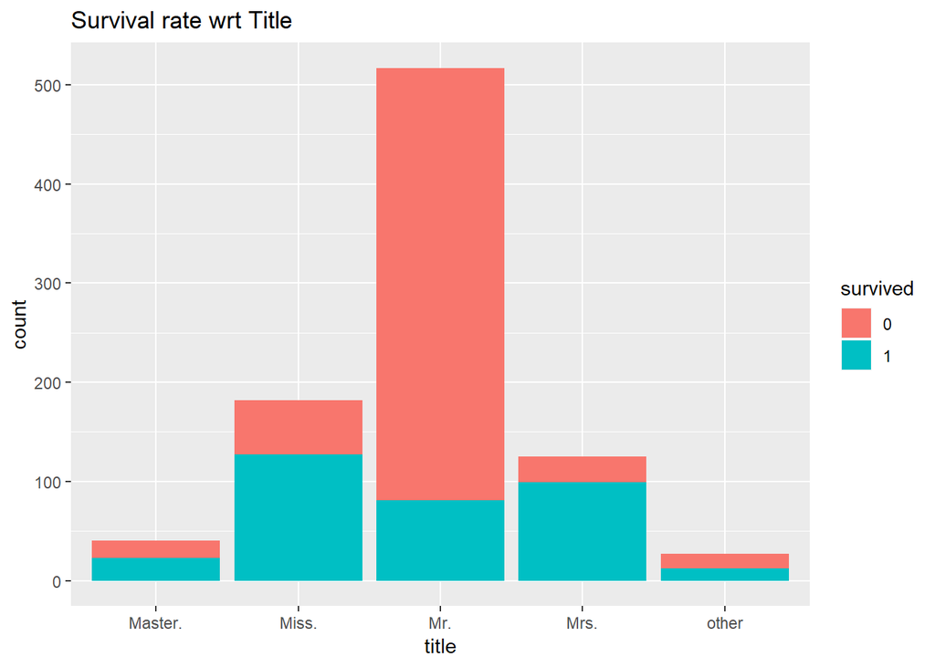

```r
#Since we only have survived lables for the train set, only use the first 891 rows

ggplot(data.combined[1:891,], aes(x=title, fill=survived)) +
  geom_bar() +
  ggtitle("Survival rate wrt Title")
```

### 5.2.3 Interpretation

The survival for Mr. is staggeringly lower compared to other titles. Let’s add pclass to see if sruvival of males traveling by first class is better.

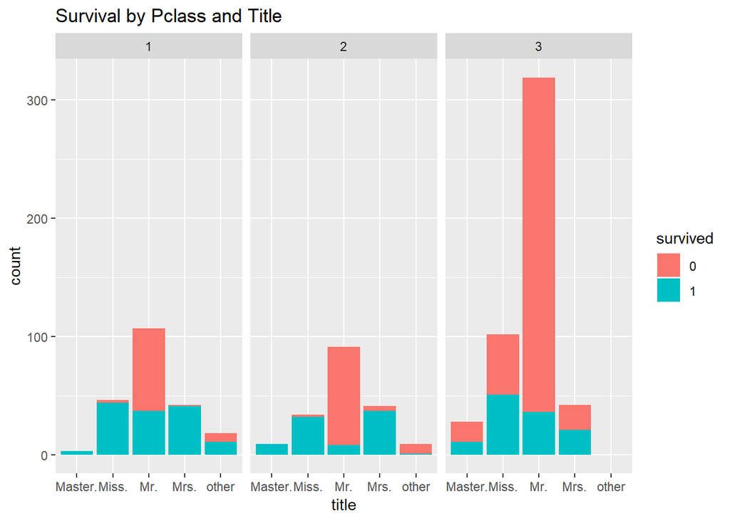

```r
ggplot(data.combined[1:891,], aes(x=title, fill=survived)) +
  geom_bar() +
    facet_wrap(~pclass) +
    ggtitle("Survival by Pclass and Title")
```

## 5.3 Explore sex feature

Let’s explore the sex variable now

```r
str(data.combined$sex)
```

```
##  Factor w/ 2 levels "female","male": 2 1 1 1 2 2 2 2 1 1 ...
```

```r
table(data.combined$sex)
```

```
##
## female   male
##    466    843
```

```r
table(data.combined$sex, data.combined$title)
```

```
##
##          Master. Miss. Mr. Mrs. other
##   female       0   260   0  197     9
##   male        61     0 757    0    25
```

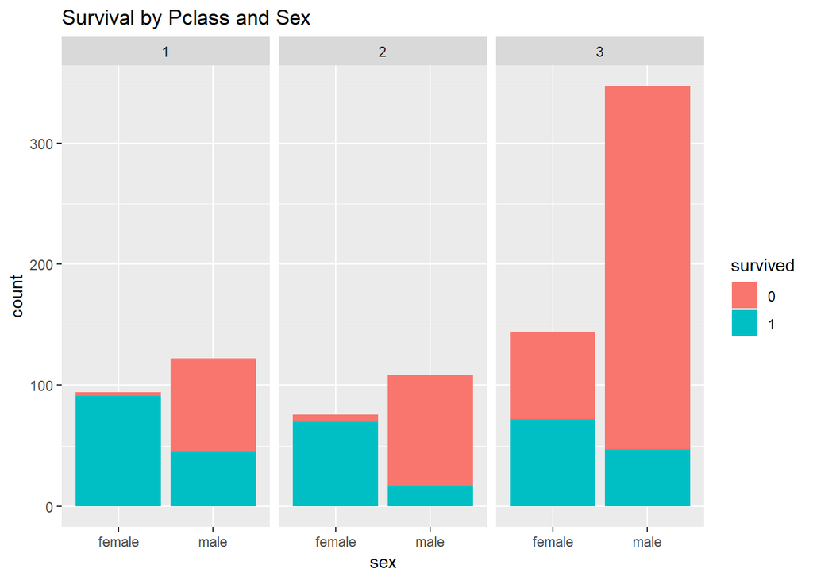

```r
# Let's visualize

ggplot(data.combined[1:891,], aes(x = sex, fill = survived)) +
  geom_bar() +
  facet_wrap(~pclass)+
  ggtitle("Survival by Pclass and Sex")
```

### 5.3.1 Interpretation

Looks like sex is a very strong predictor of survival. In all the three pclasses male survival rate is low. Females in first and second class have very high survival rate whereas in class 3 it is almost 50/50

## 5.4 Explore age feature

Let’s explore the numeric variable age

```r
str(data.combined$age)
```

```
##  num [1:1309] 22 38 26 35 35 NA 54 2 27 14 ...
```

```r
summary(data.combined$age)
```

```
##    Min. 1st Qu.  Median    Mean 3rd Qu.    Max.    NA's
##    0.17   21.00   28.00   29.88   39.00   80.00     263
```

There are many missing values

Just to be thorough, take a look at survival rates broken out by sex, pclass, and age it is a numerical variable so we will plot histogram

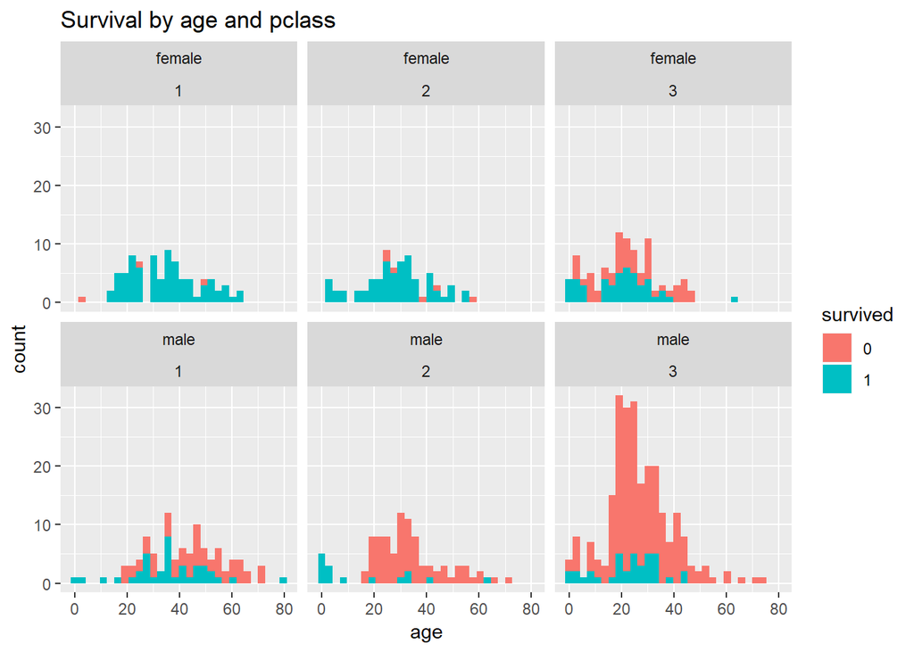

```r
ggplot(data.combined[1:861,], aes(x=age, fill=survived)) +
  geom_histogram() +
  facet_wrap(~ sex + pclass) +
  ggtitle("Survival by age and pclass")
```

### 5.4.1 Interpretation

There is lot of Age missing so we impute Age based on title and age average or median as replacement value or avg in some cases and median in some cases

let’s see the age statistics wrt Pclass and Title the older you are the wealthier you are stats and NAs for the group

```r
age.stats = train %>%
  group_by(title,pclass) %>%
  summarize(age.min = min(age, na.rm = T),
            age.max = max(age, na.rm = T),
            age.mean = mean(age, na.rm = T),
            age.median = median(age, na.rm = T),
            age.na.count = sum(is.na(age)),
            age.var = var(age, na.rm = T),
            age.sd = sd(age, na.rm = T),
            age.IQR = IQR(age, na.rm = T)) %>%
  arrange(title,pclass)

#View(age.stats)

table(train$pclass)
```

```
##
##   1   2   3
## 216 184 491
```

Rule: When mean and median are close, it is better to use mean because it a good summary statistic

Miss is an overloaded title, it covers both unmarried adult women as well as female children. So Miss is problamatic for Title as proxy for Age. So for all titles except Miss we use mean age as proxy.

Rule Imputation Steps Create Tracking feature/ indicator variable- Y for NA else N lookup table

```r
train$age.missing = ifelse(is.na(train$age), "Y","N")

table(train$age.missing)
```

```
##
##   N   Y
## 714 177
```

```r
#View(train)
```

For matching Pclass and Title we want to replace NA age with mean / median Age So we create a new df with Pclass, Title, mean Age, median Age then join original df with this df on Pclass and Title then replace Age in original with either mean Age or median Age and remove the mean Age and median Age

```r
age.lookup = age.stats %>%
  select(pclass,title,age.mean,age.median)

#View(age.lookup)


train = train %>%
  left_join(age.lookup, by=c("pclass","title")) %>%
  mutate(age = ifelse(age.missing == "Y",
                      ifelse(title == "Miss.", age.median, age.mean),
                      age) ) %>%
  select(-age.median, -age.mean)

#View(train)
```

We engineered feature title as it was proxy for gender and age

We imputed the below features

zero fares - median fares based on Pclass missing age - mean(except Miss)/median(Miss) age based on title and Pclass

Steps for imputing or replacing features

Create Tracking feature as indicator for replacing values - it helps to reverse engineer to original value if we need to later

Create a lookup table for new features using join - so we need to add the matching columns to the lookup table - left join original df with new - mutate to do the actual replacement - remove the lookup variables from original df

Here we’ll go ahead and create a whole lot of new features

look at impute Age distribution all up 5 % to 100% step by 5 percent 20 buckets

```r
quantile(train$age, probs = c(0.25,0.5,0.75))
```

```
##      25%      50%      75%
## 21.00000 28.72489 36.75000
```

```r
quantile(train$age, probs=seq(0.05, 1, 0.05))
```

```
##        5%       10%       15%       20%       25%       30%       35%
##  5.350833 16.000000 18.000000 19.000000 21.000000 22.000000 24.000000
##       40%       45%       50%       55%       60%       65%       70%
## 26.000000 28.250000 28.724891 28.724891 30.000000 33.000000 34.000000
##       75%       80%       85%       90%       95%      100%
## 36.750000 40.500000 42.382653 47.000000 54.000000 80.000000
```

5 % have age 5.3 or below 10 % have age 16 or below 15 % have age 18 or below 80% have age 40 - so it is skewed to younger

Survival based on age - children, adults, elderly

### 5.4.2 Analysing combined data without dplyr, just for comparison

Let’s see if our titles are good indicator of age and sex

```r
table(data.combined$title)
```

```
##
## Master.   Miss.     Mr.    Mrs.   other
##      61     260     757     197      34
```

```r
boys = data.combined %>% filter(title == "Master.")
summary(boys$age)
```

```
##    Min. 1st Qu.  Median    Mean 3rd Qu.    Max.    NA's
##   0.330   2.000   4.000   5.483   9.000  14.500       8
```

Maximum age is 14.5 years, that could be considered upper limit for age for title Master.

We know that “Miss.” is more complicated, let’s examine further

```r
misses = data.combined %>% filter(title == "Miss.")
summary(misses$age)
```

```
##    Min. 1st Qu.  Median    Mean 3rd Qu.    Max.    NA's
##    0.17   15.00   22.00   21.77   30.00   63.00      50
```

```r
dim(misses)
```

```
## [1] 260  12
```

```r
# Get subset of misses with survived not None and age is not NA
misses.survived = misses %>% filter(!is.na(age) & survived != "None")
dim(misses.survived)
```

```
## [1] 146  12
```

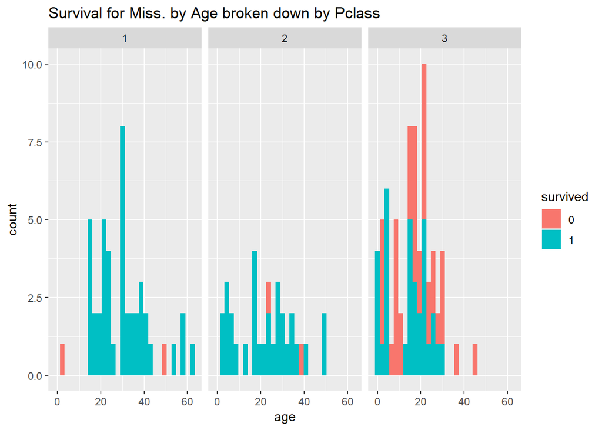

```r
# on x-axis we have age, so histogram plot, facet wrap with categorical variables pclass
ggplot(misses.survived, aes(x = age, fill = survived)) +
  geom_histogram() +
  facet_wrap(~pclass) +
  ggtitle("Survival for Miss. by Age broken down by Pclass")
```

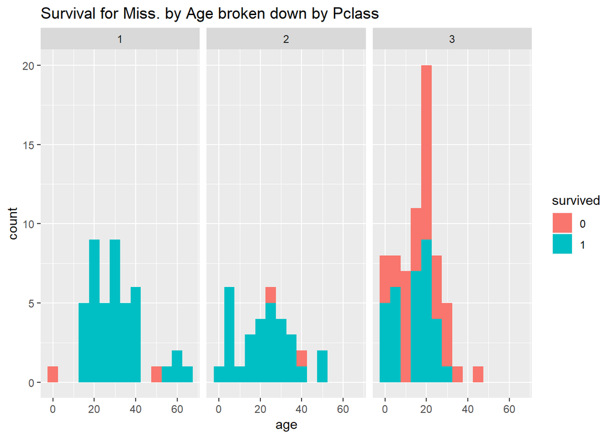

```r
# set the binwidth to 5 and plot the histogram
ggplot(misses.survived, aes(x = age, fill = survived)) +
  geom_histogram(binwidth = 5) +
  facet_wrap(~pclass) +
  ggtitle("Survival for Miss. by Age broken down by Pclass")
```

Female children may have better survival rate than adult females could be a candidate for feature engineering later

```r
#View(misses)
head(misses)
```

```
##   survived pclass                                 name    sex age sibsp
## 1        1      3               Heikkinen, Miss. Laina female  26     0
## 2        1      3      Sandstrom, Miss. Marguerite Rut female   4     1
## 3        1      1             Bonnell, Miss. Elizabeth female  58     0
## 4        0      3 Vestrom, Miss. Hulda Amanda Adolfina female  14     0
## 5        1      3          McGowan, Miss. Anna "Annie" female  15     0
## 6        0      3        Palsson, Miss. Torborg Danira female   8     3
##   parch           ticket    fare cabin embarked title
## 1     0 STON/O2. 3101282  7.9250              S Miss.
## 2     1          PP 9549 16.7000    G6        S Miss.
## 3     0           113783 26.5500  C103        S Miss.
## 4     0           350406  7.8542              S Miss.
## 5     0           330923  8.0292              Q Miss.
## 6     1           349909 21.0750              S Miss.
```

```r
# Let's find females traveling alone, that is without parents, siblings, spouse
misses.alone = misses %>% filter(parch == 0 & sibsp == 0)

dim(misses.alone)
```

```
## [1] 150  12
```

```r
summary(misses.alone$age)
```

```
##    Min. 1st Qu.  Median    Mean 3rd Qu.    Max.    NA's
##    5.00   21.00   26.00   27.23   32.50   58.00      33
```

```r
length(which(misses.alone$age <= 14.5))
```

```
## [1] 4
```

## 5.5 Explore sibsp variable

Let’s explore the sibsp variable using data.combined dataset

```r
str(data.combined$sibsp)
```

```
##  int [1:1309] 1 1 0 1 0 0 0 3 0 1 ...
```

```r
summary(data.combined$sibsp)
```

```
##    Min. 1st Qu.  Median    Mean 3rd Qu.    Max.
##  0.0000  0.0000  0.0000  0.4989  1.0000  8.0000
```

```r
# Can we treat as a factor?
length(unique(data.combined$sibsp))
```

```
## [1] 7
```

```r
unique(data.combined$sibsp)
```

```
## [1] 1 0 3 4 2 5 8
```

```r
table(data.combined$sibsp)
```

```
##
##   0   1   2   3   4   5   8
## 891 319  42  20  22   6   9
```

```r
data.combined$sibsp <- as.factor(data.combined$sibsp)
```

Of the five variables we have explored before: names, from which we derived title, plcass, sex, age title represents age and sex and title & pclass have predictive power so let’s visualize survival wrt sibsp broken down by title and pclass

x-axis has sibsp which factor so bar plot facet wraped with other factor variables pclass and title

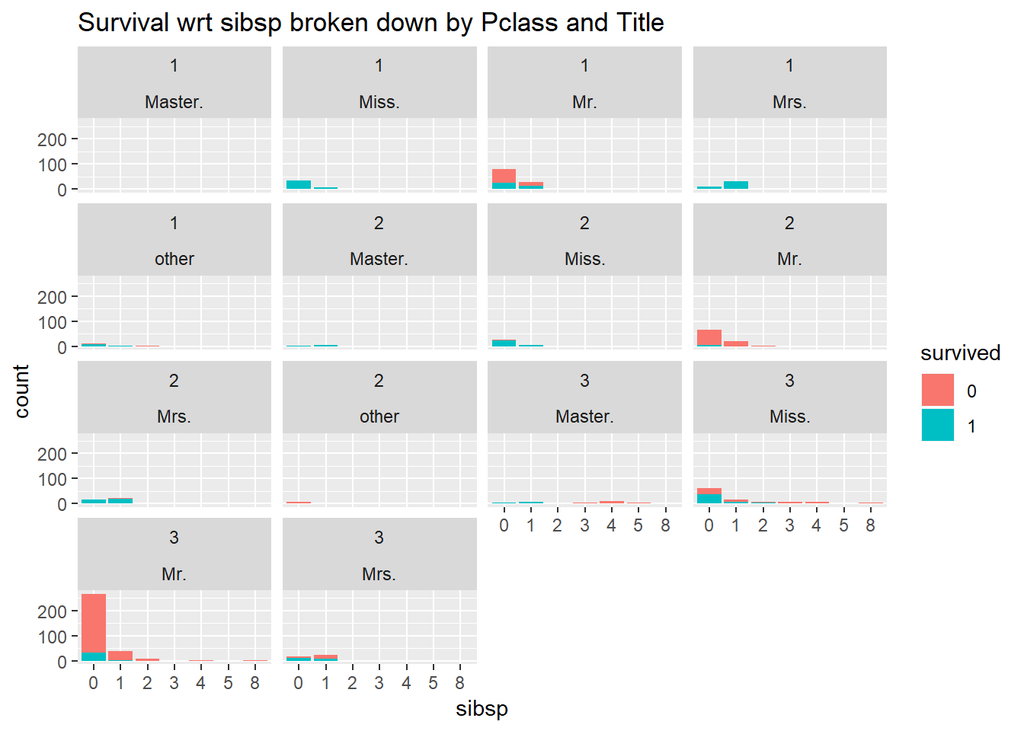

```r
ggplot(data.combined[1:891,], aes(x = sibsp, fill = survived)) +
  geom_bar() +
  facet_wrap(~pclass + title) +
  ggtitle("Survival wrt sibsp broken down by Pclass and Title")
```

## 5.6 Explore parch variable

Let’s explore the parch variable for data.combined dataset

```r
str(data.combined$parch)
```

```
##  int [1:1309] 0 0 0 0 0 0 0 1 2 0 ...
```

```r
length(unique(data.combined$parch))
```

```
## [1] 8
```

```r
unique(data.combined$parch)
```

```
## [1] 0 1 2 5 3 4 6 9
```

```r
# convert it to factor and visualize to see if it has any predictive power
data.combined$parch = as.factor(data.combined$parch)
str(data.combined$parch)
```

```
##  Factor w/ 8 levels "0","1","2","3",..: 1 1 1 1 1 1 1 2 3 1 ...
```

```r
table(data.combined$parch)
```

```
##
##    0    1    2    3    4    5    6    9
## 1002  170  113    8    6    6    2    2
```

Most passengers are traveling alone, there are 2 passengers with parch size 9

x-axis parch which is factor so bar plot broken down by categorical variable pclass and title

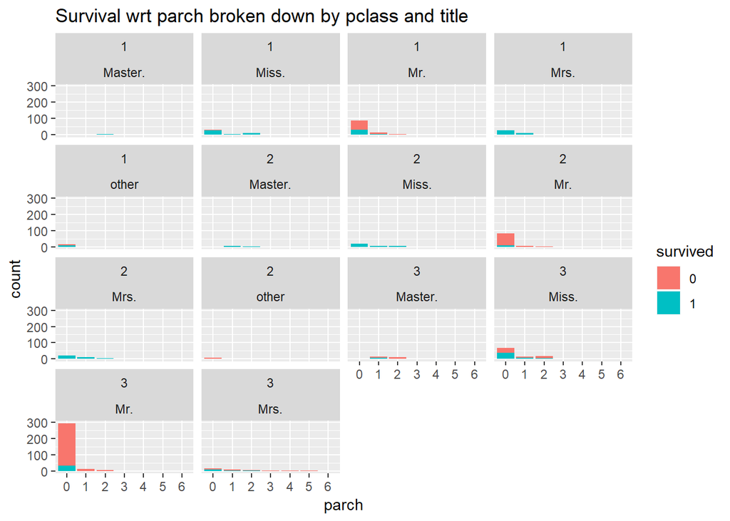

```r
ggplot(data.combined[1:891, ], aes(x = parch, fill = survived)) +
  geom_bar() +
  facet_wrap(~pclass + title) +
  ggtitle("Survival wrt parch broken down by pclass and title")
```

### 5.6.1 New feature family size

Let’s create a new feature family_size

A passenger who has parch or sbsp value non-zero implies is traveling with family sbsp is for spouse and parch is for parch If passenger is traveling with spouse, sbsp is 1 and if they have children the parch will have number of children traveling with them. If pasenger is child parch is either 0 or 1 or 2, if passenger is adult then parch is number of children

If passenger is traveling with sibling, sbsp is number of siblings and parch is number of parents 0 or 1 or 2

So family size siblings/spouse plus parch plus the individual passenger count

```r
# Let's view family with size 8

big_family = data.combined %>% filter(parch == 9)
#View(big_family)

# The ticket number is CA. 2343, let's see all passengers with that ticket number

big_family_members = data.combined %>% filter(ticket == "CA. 2343")
#View(big_family_members)
big_family_members
```

```
##    survived pclass                              name    sex  age sibsp
## 1         0      3        Sage, Master. Thomas Henry   male   NA     8
## 2         0      3      Sage, Miss. Constance Gladys female   NA     8
## 3         0      3               Sage, Mr. Frederick   male   NA     8
## 4         0      3          Sage, Mr. George John Jr   male   NA     8
## 5         0      3           Sage, Miss. Stella Anna female   NA     8
## 6         0      3          Sage, Mr. Douglas Bullen   male   NA     8
## 7         0      3 Sage, Miss. Dorothy Edith "Dolly" female   NA     8
## 8      None      3                   Sage, Miss. Ada female   NA     8
## 9      None      3             Sage, Mr. John George   male   NA     1
## 10     None      3       Sage, Master. William Henry   male 14.5     8
## 11     None      3    Sage, Mrs. John (Annie Bullen) female   NA     1
##    parch   ticket  fare cabin embarked   title
## 1      2 CA. 2343 69.55              S Master.
## 2      2 CA. 2343 69.55              S   Miss.
## 3      2 CA. 2343 69.55              S     Mr.
## 4      2 CA. 2343 69.55              S     Mr.
## 5      2 CA. 2343 69.55              S   Miss.
## 6      2 CA. 2343 69.55              S     Mr.
## 7      2 CA. 2343 69.55              S   Miss.
## 8      2 CA. 2343 69.55              S   Miss.
## 9      9 CA. 2343 69.55              S     Mr.
## 10     2 CA. 2343 69.55              S Master.
## 11     9 CA. 2343 69.55              S    Mrs.
```

Mr and Mrs Sage are traveling with 9 children, each child has 8 siblings so the family size is 9 children plus the couple that is 11

```r
str(data.combined$parch)
```

```
##  Factor w/ 8 levels "0","1","2","3",..: 1 1 1 1 1 1 1 2 3 1 ...
```

```r
str(data.combined$sibsp)
```

```
##  Factor w/ 7 levels "0","1","2","3",..: 2 2 1 2 1 1 1 4 1 2 ...
```

```r
#Since we have parch and sibsp are factors, we have to convert the levels
#to numeric to add

as.numeric(big_family_members$parch)
```

```
##  [1] 3 3 3 3 3 3 3 3 8 3 8
```

```r
# Values of factors, can be converted to character then numeric
as.character(big_family_members$parch)
```

```
##  [1] "2" "2" "2" "2" "2" "2" "2" "2" "9" "2" "9"
```

```r
as.numeric(as.character(big_family_members$parch))
```

```
##  [1] 2 2 2 2 2 2 2 2 9 2 9
```

```r
as.numeric(big_family_members$sibsp)
```

```
##  [1] 7 7 7 7 7 7 7 7 2 7 2
```

```r
#This also returns the level assigned to the value of factor

# To get the actual value, get the character value then convert it to numeric
as.character(big_family_members$sibsp)
```

```
##  [1] "8" "8" "8" "8" "8" "8" "8" "8" "1" "8" "1"
```

```r
as.numeric(as.character(big_family_members$sibsp))
```

```
##  [1] 8 8 8 8 8 8 8 8 1 8 1
```

```r
#Let's apply for the entire dataset to get the family size
temp.parch = as.numeric(as.character(data.combined$parch))
head(temp.parch)
```

```
## [1] 0 0 0 0 0 0
```

```r
str(temp.parch)
```

```
##  num [1:1309] 0 0 0 0 0 0 0 1 2 0 ...
```

```r
temp.sibsp = as.numeric(as.character(data.combined$sibsp))
head(temp.sibsp)
```

```
## [1] 1 1 0 1 0 0
```

```r
str(temp.sibsp)
```

```
##  num [1:1309] 1 1 0 1 0 0 0 3 0 1 ...
```

```r
data.combined$family.size = as.factor(temp.parch + temp.sibsp + 1)
#View(head(data.combined))
head(data.combined)
```

```
##   survived pclass                                                name
## 1        0      3                             Braund, Mr. Owen Harris
## 2        1      1 Cumings, Mrs. John Bradley (Florence Briggs Thayer)
## 3        1      3                              Heikkinen, Miss. Laina
## 4        1      1        Futrelle, Mrs. Jacques Heath (Lily May Peel)
## 5        0      3                            Allen, Mr. William Henry
## 6        0      3                                    Moran, Mr. James
##      sex age sibsp parch           ticket    fare cabin embarked title
## 1   male  22     1     0        A/5 21171  7.2500              S   Mr.
## 2 female  38     1     0         PC 17599 71.2833   C85        C  Mrs.
## 3 female  26     0     0 STON/O2. 3101282  7.9250              S Miss.
## 4 female  35     1     0           113803 53.1000  C123        S  Mrs.
## 5   male  35     0     0           373450  8.0500              S   Mr.
## 6   male  NA     0     0           330877  8.4583              Q   Mr.
##   family.size
## 1           2
## 2           2
## 3           1
## 4           2
## 5           1
## 6           1
```

```r
big_family_members = data.combined %>% filter(ticket == "CA. 2343")
#View(big_family_members)
big_family_members
```

```
##    survived pclass                              name    sex  age sibsp
## 1         0      3        Sage, Master. Thomas Henry   male   NA     8
## 2         0      3      Sage, Miss. Constance Gladys female   NA     8
## 3         0      3               Sage, Mr. Frederick   male   NA     8
## 4         0      3          Sage, Mr. George John Jr   male   NA     8
## 5         0      3           Sage, Miss. Stella Anna female   NA     8
## 6         0      3          Sage, Mr. Douglas Bullen   male   NA     8
## 7         0      3 Sage, Miss. Dorothy Edith "Dolly" female   NA     8
## 8      None      3                   Sage, Miss. Ada female   NA     8
## 9      None      3             Sage, Mr. John George   male   NA     1
## 10     None      3       Sage, Master. William Henry   male 14.5     8
## 11     None      3    Sage, Mrs. John (Annie Bullen) female   NA     1
##    parch   ticket  fare cabin embarked   title family.size
## 1      2 CA. 2343 69.55              S Master.          11
## 2      2 CA. 2343 69.55              S   Miss.          11
## 3      2 CA. 2343 69.55              S     Mr.          11
## 4      2 CA. 2343 69.55              S     Mr.          11
## 5      2 CA. 2343 69.55              S   Miss.          11
## 6      2 CA. 2343 69.55              S     Mr.          11
## 7      2 CA. 2343 69.55              S   Miss.          11
## 8      2 CA. 2343 69.55              S   Miss.          11
## 9      9 CA. 2343 69.55              S     Mr.          11
## 10     2 CA. 2343 69.55              S Master.          11
## 11     9 CA. 2343 69.55              S    Mrs.          11
```

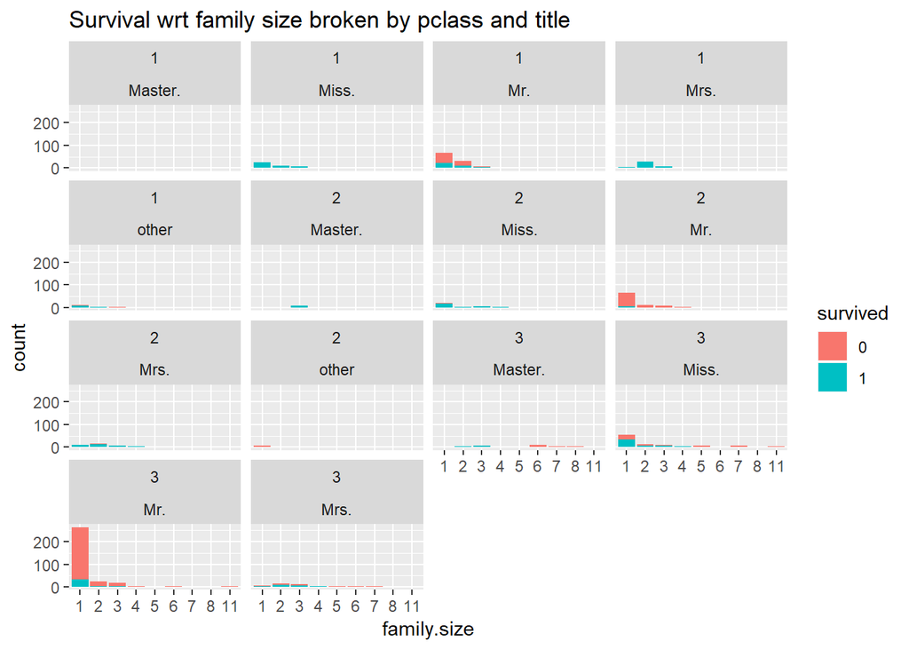

```r
# Let's visualize to see if family.size has any predictive power
#x-axis family size which is factor so use bar plot broken by pclass and title

ggplot(data.combined[1:891,], aes(x = family.size, fill = survived)) +
  geom_bar() +
  facet_wrap(~ pclass + title) +
  ggtitle("Survival wrt family size broken by pclass and title")
```

## 5.7 Explore ticket feature

Let’s explore the ticket variable.

Tickets were bought for group not individual tickets for each seat as in modern day based on individuals with same ticket. Fare can be calculated for each individual based on title and age

```r
# group by tickets and engineer below 13 features

ticket.lookup = train %>%
  group_by(ticket) %>%
  summarize(group.count = n(),
            avg.fare = max(fare)/n(),
            female.count = sum(sex == "female"),
            male.count = sum(sex == "male"),
            child.count = sum(age < 18),
            elderly.count = sum(age > 54.0),
            female.ratio = sum(sex == "female")/n(),
            male.ratio = sum(sex == "male")/n(),
            child.ratio = sum(age < 18)/n(),
            elderly.ratio = sum(age > 54.0)/n(),
            female.child.ratio = ( sum(age <18) +
                                     sum(sex == "female" & age >= 18))/n(),
            min.age = min(age),
            max.age = max(age))



group_tickets = train %>%
  group_by(ticket) %>%
  summarise(n = n()) %>%
  filter( n > 1)

glimpse(group_tickets)
```

```
## Observations: 134
## Variables: 2
## $ ticket <fct> 110152, 110413, 110465, 111361, 113505, 113572, 113760,...
## $ n      <int> 3, 3, 2, 2, 2, 2, 4, 2, 4, 2, 2, 2, 2, 2, 2, 2, 2, 2, 3...
```

```r
sum(group_tickets$n)
```

```
## [1] 344
```

```r
group_tickets %>% filter(ticket == "3101295")
```

```
## # A tibble: 1 x 2
##   ticket      n
##   <fct>   <int>
## 1 3101295     6
```

```r
#View(group_tickets %>% filter(ticket == "3101295"))
head(group_tickets %>% filter(ticket == "3101295"))
```

```
## # A tibble: 1 x 2
##   ticket      n
##   <fct>   <int>
## 1 3101295     6
```

```r
single_tickets = train %>%
  group_by(ticket) %>%
  summarise(n = n()) %>%
  filter( n == 1)
sum(single_tickets$n)
```

```
## [1] 547
```

```r
glimpse(single_tickets)
```

```
## Observations: 547
## Variables: 2
## $ ticket <fct> 110564, 110813, 111240, 111320, 111369, 111426, 111427,...
## $ n      <int> 1, 1, 1, 1, 1, 1, 1, 1, 1, 1, 1, 1, 1, 1, 1, 1, 1, 1, 1...
```

```r
#View(ticket.lookup)
head(ticket.lookup)
```

```
## # A tibble: 6 x 14
##   ticket group.count avg.fare female.count male.count child.count
##   <fct>        <int>    <dbl>        <int>      <int>       <int>
## 1 110152           3     28.8            3          0           1
## 2 110413           3     26.6            2          1           0
## 3 110465           2     26              0          2           0
## 4 110564           1     26.6            0          1           0
## 5 110813           1     75.2            1          0           0
## 6 111240           1     33.5            0          1           0
## # ... with 8 more variables: elderly.count <int>, female.ratio <dbl>,
## #   male.ratio <dbl>, child.ratio <dbl>, elderly.ratio <dbl>,
## #   female.child.ratio <dbl>, min.age <dbl>, max.age <dbl>
```

```r
names(train)
```

```
##  [1] "survived"    "pclass"      "name"        "sex"         "age"
##  [6] "sibsp"       "parch"       "ticket"      "fare"        "cabin"
## [11] "embarked"    "title"       "age.missing"
```

```r
#Double-check our work
ticket.lookup %>% filter(ticket == "3101295")
```

```
## # A tibble: 1 x 14
##   ticket group.count avg.fare female.count male.count child.count
##   <fct>        <int>    <dbl>        <int>      <int>       <int>
## 1 31012~           6     6.61            1          5           5
## # ... with 8 more variables: elderly.count <int>, female.ratio <dbl>,
## #   male.ratio <dbl>, child.ratio <dbl>, elderly.ratio <dbl>,
## #   female.child.ratio <dbl>, min.age <dbl>, max.age <dbl>
```

```r
#View(ticket.lookup %>% filter(ticket == "3101295"))
head(ticket.lookup %>% filter(ticket == "3101295"))
```

```
## # A tibble: 1 x 14
##   ticket group.count avg.fare female.count male.count child.count
##   <fct>        <int>    <dbl>        <int>      <int>       <int>
## 1 31012~           6     6.61            1          5           5
## # ... with 8 more variables: elderly.count <int>, female.ratio <dbl>,
## #   male.ratio <dbl>, child.ratio <dbl>, elderly.ratio <dbl>,
## #   female.child.ratio <dbl>, min.age <dbl>, max.age <dbl>
```

```r
#View(train %>% filter(ticket == "3101295"))
head(train %>% filter(ticket == "3101295"))
```

```
##   survived pclass                                   name    sex age sibsp
## 1        0      3             Panula, Master. Juha Niilo   male   7     4
## 2        0      3           Panula, Master. Eino Viljami   male   1     4
## 3        0      3              Panula, Mr. Ernesti Arvid   male  16     4
## 4        0      3 Panula, Mrs. Juha (Maria Emilia Ojala) female  41     0
## 5        0      3               Panula, Mr. Jaako Arnold   male  14     4
## 6        0      3           Panula, Master. Urho Abraham   male   2     4
##   parch  ticket    fare cabin embarked   title age.missing
## 1     1 3101295 39.6875              S Master.           N
## 2     1 3101295 39.6875              S Master.           N
## 3     1 3101295 39.6875              S     Mr.           N
## 4     5 3101295 39.6875              S    Mrs.           N
## 5     1 3101295 39.6875              S     Mr.           N
## 6     1 3101295 39.6875              S Master.           N
```

```r
# Now lets add all the new features to the original df
train = train %>%
  left_join(ticket.lookup, by = "ticket")

#View(train %>% filter(ticket == "3101295"))
head(train %>% filter(ticket == "3101295"))
```

```
##   survived pclass                                   name    sex age sibsp
## 1        0      3             Panula, Master. Juha Niilo   male   7     4
## 2        0      3           Panula, Master. Eino Viljami   male   1     4
## 3        0      3              Panula, Mr. Ernesti Arvid   male  16     4
## 4        0      3 Panula, Mrs. Juha (Maria Emilia Ojala) female  41     0
## 5        0      3               Panula, Mr. Jaako Arnold   male  14     4
## 6        0      3           Panula, Master. Urho Abraham   male   2     4
##   parch  ticket    fare cabin embarked   title age.missing group.count
## 1     1 3101295 39.6875              S Master.           N           6
## 2     1 3101295 39.6875              S Master.           N           6
## 3     1 3101295 39.6875              S     Mr.           N           6
## 4     5 3101295 39.6875              S    Mrs.           N           6
## 5     1 3101295 39.6875              S     Mr.           N           6
## 6     1 3101295 39.6875              S Master.           N           6
##   avg.fare female.count male.count child.count elderly.count female.ratio
## 1 6.614583            1          5           5             0    0.1666667
## 2 6.614583            1          5           5             0    0.1666667
## 3 6.614583            1          5           5             0    0.1666667
## 4 6.614583            1          5           5             0    0.1666667
## 5 6.614583            1          5           5             0    0.1666667
## 6 6.614583            1          5           5             0    0.1666667
##   male.ratio child.ratio elderly.ratio female.child.ratio min.age max.age
## 1  0.8333333   0.8333333             0                  1       1      41
## 2  0.8333333   0.8333333             0                  1       1      41
## 3  0.8333333   0.8333333             0                  1       1      41
## 4  0.8333333   0.8333333             0                  1       1      41
## 5  0.8333333   0.8333333             0                  1       1      41
## 6  0.8333333   0.8333333             0                  1       1      41
```

```r
names(train)
```

```
##  [1] "survived"           "pclass"             "name"
##  [4] "sex"                "age"                "sibsp"
##  [7] "parch"              "ticket"             "fare"
## [10] "cabin"              "embarked"           "title"
## [13] "age.missing"        "group.count"        "avg.fare"
## [16] "female.count"       "male.count"         "child.count"
## [19] "elderly.count"      "female.ratio"       "male.ratio"
## [22] "child.ratio"        "elderly.ratio"      "female.child.ratio"
## [25] "min.age"            "max.age"
```

### 5.7.1 Analysing ticket variable for combined data without dplyr

```r
str(data.combined$ticket)
```

```
##  chr [1:1309] "A/5 21171" "PC 17599" "STON/O2. 3101282" "113803" ...
```

```r
head(data.combined$ticket)
```

```
## [1] "A/5 21171"        "PC 17599"         "STON/O2. 3101282"
## [4] "113803"           "373450"           "330877"
```

```r
data.combined$ticket[1:20]
```

```
##  [1] "A/5 21171"        "PC 17599"         "STON/O2. 3101282"
##  [4] "113803"           "373450"           "330877"
##  [7] "17463"            "349909"           "347742"
## [10] "237736"           "PP 9549"          "113783"
## [13] "A/5. 2151"        "347082"           "350406"
## [16] "248706"           "382652"           "244373"
## [19] "345763"           "2649"
```

There’s no immediately apparent structure in the data, let’s see if we can find some. We’ll start with taking a look at just the first char for each.

```r
# if empty ticket string replace with space o.w extract the first character
ticket.first.char = ifelse(data.combined$ticket == ""," ",
                           substr(data.combined$ticket,1,1))

#View(ticket.first.char)
head(ticket.first.char)
```

```
## [1] "A" "P" "S" "1" "3" "3"
```

```r
sum(is.na(ticket.first.char))
```

```
## [1] 0
```

```r
length(unique(ticket.first.char))
```

```
## [1] 16
```

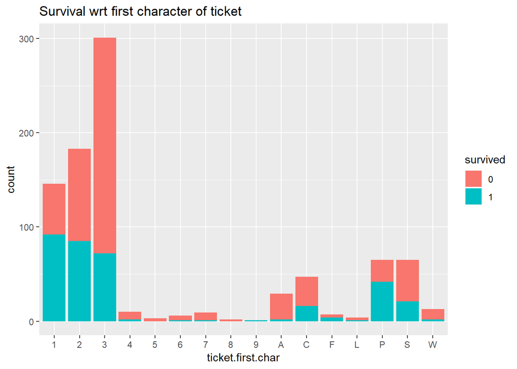

```r
#Let's add this as new feature and convert to factor
data.combined$ticket.first.char = as.factor(ticket.first.char)


# First high-level plot
#x-axis ticket.first.char is factor so bar plot, fill with label survived

ggplot(data.combined[1:891,], aes(x = ticket.first.char, fill = survived)) +
  geom_bar() +
  ggtitle("Survival wrt first character of ticket")
```

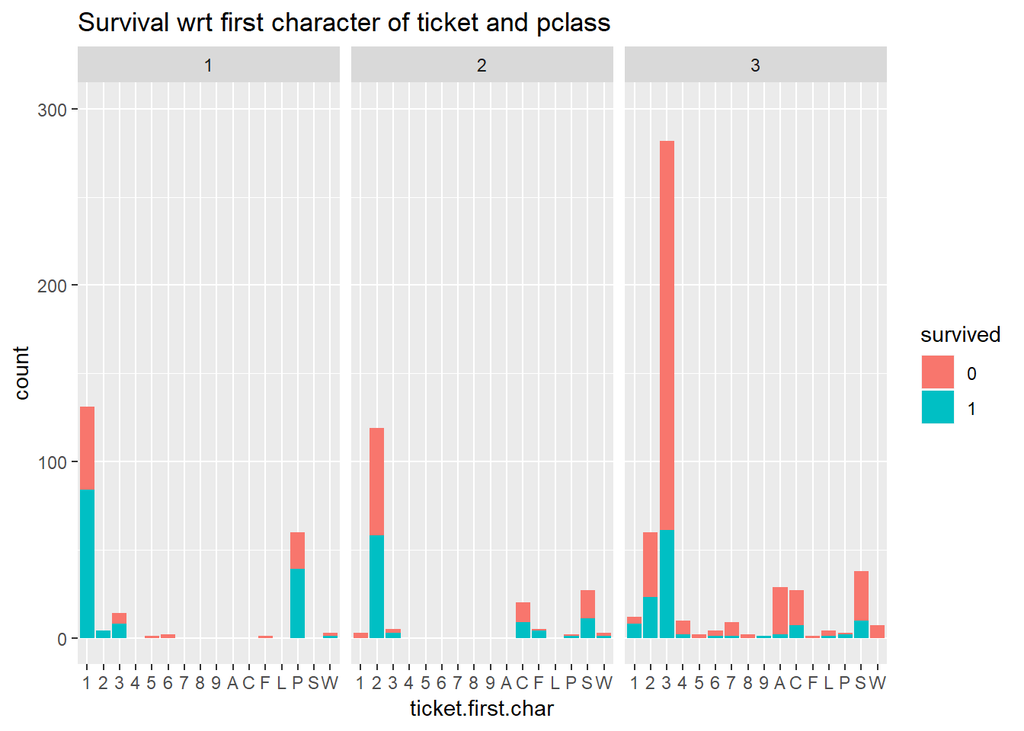

```r
#Looks like ticket number might be predictive, let's break down further wrt pclass
ggplot(data.combined[1:891,], aes(x = ticket.first.char, fill = survived)) +
  geom_bar() +
  facet_wrap(~pclass) +
  ylim(0,300) +
  ggtitle("Survival wrt first character of ticket and pclass")
```

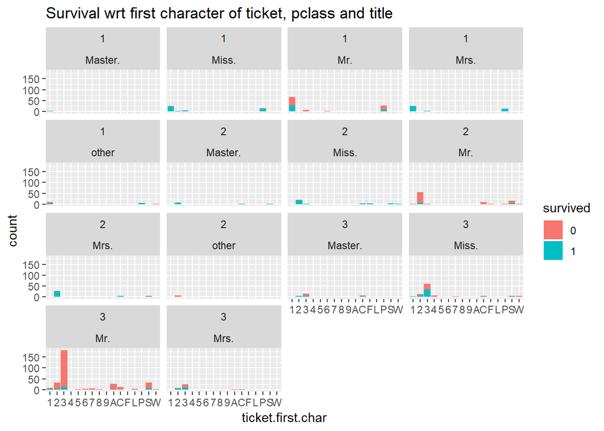

```r
# Lastly, see if we get a pattern when using combination of pclass & title
ggplot(data.combined[1:891,], aes(x = ticket.first.char, fill = survived)) +
    geom_bar() +
    facet_wrap(~pclass+title) +
    ggtitle("Survival wrt first character of ticket, pclass and title")
```

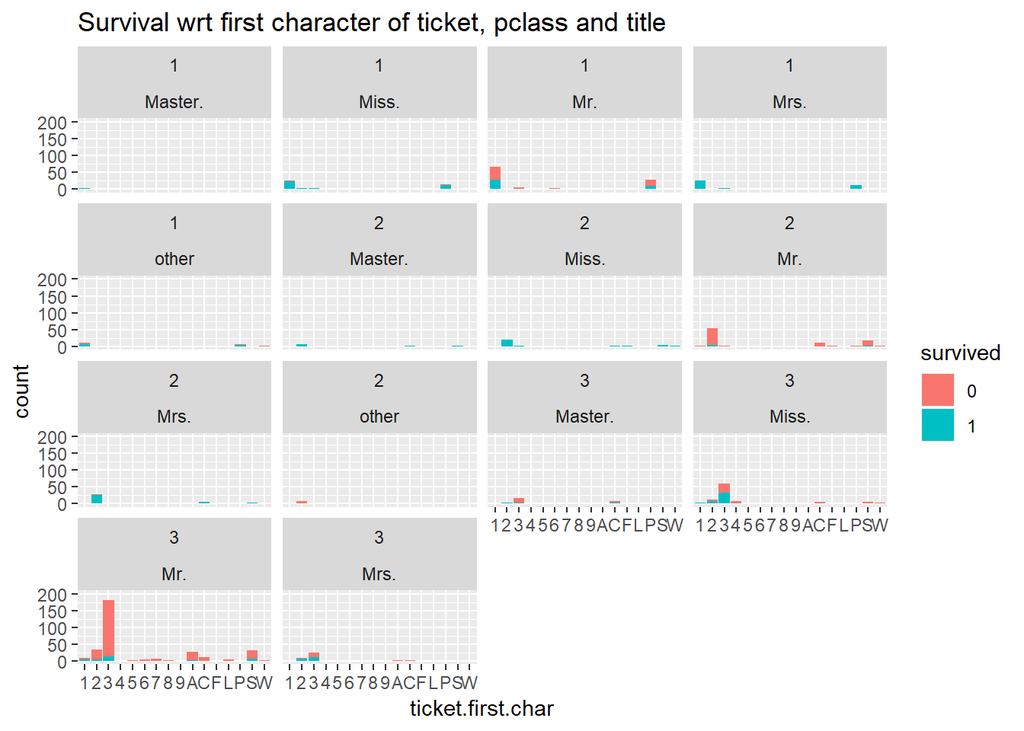

```r
ggplot(data.combined[1:891,], aes(x = ticket.first.char, fill = survived)) +
    geom_bar() +
    facet_wrap(~pclass+title) +
    ylim(0,200) +
    ggtitle("Survival wrt first character of ticket, pclass and title")
```

## 5.8 Explore fares feature

Let’s explore the fares variable to see if it has any predictive power to determine survival of passengers

```r
str(data.combined$fare)
```

```
##  num [1:1309] 7.25 71.28 7.92 53.1 8.05 ...
```

```r
summary(data.combined$fare)
```

```
##    Min. 1st Qu.  Median    Mean 3rd Qu.    Max.    NA's
##   0.000   7.896  14.454  33.295  31.275 512.329       1
```

```r
# Visualization

# Can't make fare a factor, treat as numeric & visualize with histogram
"
x-axis fare is numeric so histogram, let's just see the distribution for fare
"
```

```
## [1] "\nx-axis fare is numeric so histogram, let's just see the distribution for fare\n"
```

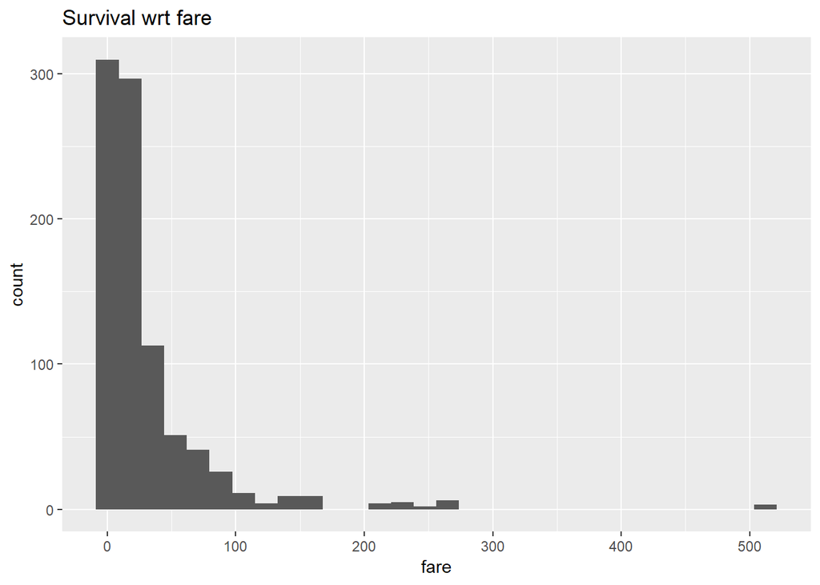

```r
ggplot(data.combined[1:891,], aes(x = fare))    +
  geom_histogram() +
  ggtitle("Survival wrt fare")
```

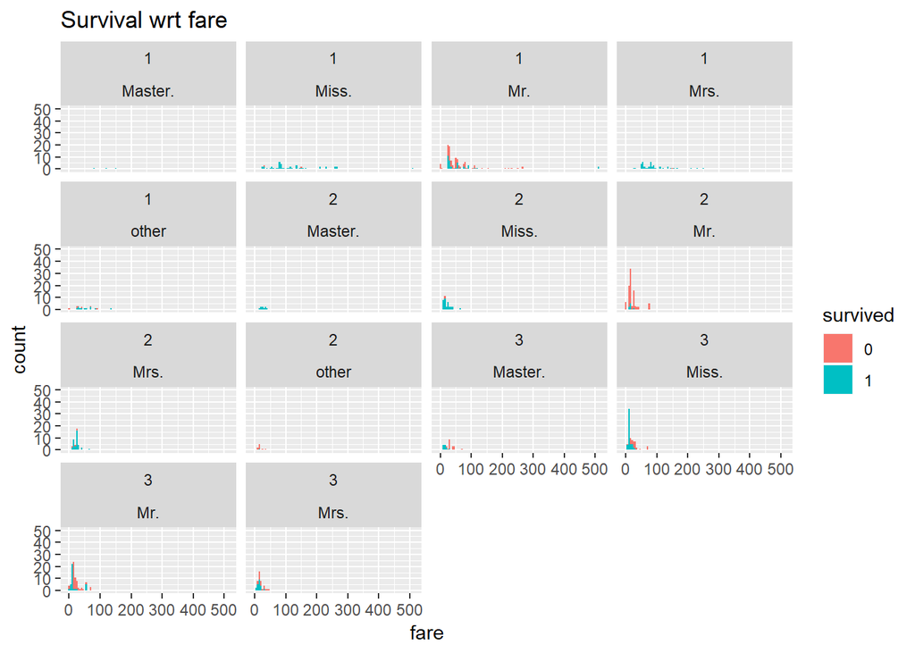

```r
# Let's check to see if fare has predictive power
ggplot(data.combined[1:891,], aes(x = fare, fill = survived))    +
  geom_histogram(binwidth = 5) +
  facet_wrap(~pclass + title) +
  ylim(0,50) +
  ggtitle("Survival wrt fare")
```

### 5.8.1 Imputate missing fares

What’s with zero fares How many passengers have zero fare? Get the subset

```r
zero.fare = train %>% filter(fare == 0.0)

#View(zero.fare)
head(zero.fare)
```

```
##   survived pclass                            name  sex      age sibsp
## 1        0      3             Leonard, Mr. Lionel male 36.00000     0
## 2        0      1           Harrison, Mr. William male 40.00000     0
## 3        1      3    Tornquist, Mr. William Henry male 25.00000     0
## 4        0      2     Parkes, Mr. Francis "Frank" male 33.58889     0
## 5        0      3 Johnson, Mr. William Cahoone Jr male 19.00000     0
## 6        0      2  Cunningham, Mr. Alfred Fleming male 33.58889     0
##   parch ticket fare cabin embarked title age.missing group.count avg.fare
## 1     0   LINE    0              S   Mr.           N           4        0
## 2     0 112059    0   B94        S   Mr.           N           1        0
## 3     0   LINE    0              S   Mr.           N           4        0
## 4     0 239853    0              S   Mr.           Y           3        0
## 5     0   LINE    0              S   Mr.           N           4        0
## 6     0 239853    0              S   Mr.           Y           3        0
##   female.count male.count child.count elderly.count female.ratio
```

[output cut: 20 more lines]

```r
dim(zero.fare)
```

```
## [1] 15 26
```

15 out of 891

They’re all males traveling alone not specific to any class and they all embarked in ‘S’. All but one perished. This is a classification problem to train model to accurately predict label Survival If we only had this data or zero.fare, 14 out 15 perished, so if we predicted that if fare is zero predict perished the model would be 93 % accurate

14/15*100

But this data is so skewed, all males, all embarked S. So let’s explore this data further

```r
# Let's get the totals by Pclass
# n() is function in dplyr, total number of observations in each group

zero.fare.pclass = zero.fare %>%
  group_by(pclass) %>%
  summarise(total = n()) %>%
  arrange(desc(total))
```

summarize - how many observations in each groups. How many observations in each Pclass

```r
zero.fare.pclass
```

```
## # A tibble: 3 x 2
##   pclass total
##    <int> <int>
## 1      2     6
## 2      1     5
## 3      3     4
```

So it is clear that zero.fare is not specific to any class " What is the distribution of fare for passengers similar to fare 0.0 so that we can replace the 0.0 value for example, replace 0 fare for male in class 3 with mean or median fare of males in class 3

zero fares are all males travelling alone so we can say they’re all adult males

We can find the avg fare for adult males travelling alone

Most of the zero fares for males, that is title Mr. So we use this correlation between title and fares to impute the zero fares

Now going back to zero fares impute zero fares we’ll use replacement , you can also use a model to predict the fares for males group by Pclass. Beauty of dplyr is that the results can be stored as dataframe

Finding the summary of fares for males grouped by Pclass. summarise is for aggregate functions we will see which of the statistics we can use to impute fare

```r
mr.fare.stats = train %>%
  filter(title == "Mr.") %>%
  group_by(pclass) %>%
  summarise(fare.Min = min(fare),
            fare.Max = max(fare),
            fare.Median = median(fare),
            fare.Var = var(fare),
            fare.SD = sd(fare),
            fare.IQR = IQR(fare))


#View(mr.fare.stats)
head(mr.fare.stats)
```

```
## # A tibble: 3 x 7
##   pclass fare.Min fare.Max fare.Median fare.Var fare.SD fare.IQR
##    <int>    <dbl>    <dbl>       <dbl>    <dbl>   <dbl>    <dbl>
## 1      1        0    512.        39.6     6079.    78.0   49.3
## 2      2        0     73.5       13        231.    15.2   14.5
## 3      3        0     69.6        7.90     109.    10.4    0.917
```

```r
str(mr.fare.stats)
```

```
## Classes 'tbl_df', 'tbl' and 'data.frame':    3 obs. of  7 variables:
##  $ pclass     : int  1 2 3
##  $ fare.Min   : num  0 0 0
##  $ fare.Max   : num  512.3 73.5 69.5
##  $ fare.Median: num  39.6 13 7.9
##  $ fare.Var   : num  6079 231 109
##  $ fare.SD    : num  78 15.2 10.4
##  $ fare.IQR   : num  49.288 14.5 0.917
```

```r
#The above can be done as below
summary(train$fare[train$title == "Mr." & train$pclass == 1])
```

```
##    Min. 1st Qu.  Median    Mean 3rd Qu.    Max.
##    0.00   27.72   39.60   65.95   77.01  512.33
```

And you have to repeat for each Pclass,that for 2, 3 and it won’t be in tabular format, so the above code is definitely more elegant because we can see the results in data frame

```r
#mean/median
11.29976/7.8958
```

```
## [1] 1.43111
```

1.43111 amost 1.5 times bigger

```r
11.29976/7.8958*100
```

```
## [1] 143.111
```

mean is almost 43 percent more than median fare is same for each member of family so big families may have skewed the fare so it makes sense to use median to impute fare

In order to not lose the original data so that if imputed values do not improve prediction accuracy we can revert to original values,we use tracking features for that

Create “tracking feature” for those records that originally had 0.0 for the Fare variable. Common practise in Data Science to identify imputed value.

```r
train$fare.zero = ifelse(train$fare == 0.0, "Y", "N")

head(train)
```

```
##   survived pclass                                                name
## 1        0      3                             Braund, Mr. Owen Harris
## 2        1      1 Cumings, Mrs. John Bradley (Florence Briggs Thayer)
## 3        1      3                              Heikkinen, Miss. Laina
## 4        1      1        Futrelle, Mrs. Jacques Heath (Lily May Peel)
## 5        0      3                            Allen, Mr. William Henry
## 6        0      3                                    Moran, Mr. James
##      sex      age sibsp parch           ticket    fare cabin embarked
## 1   male 22.00000     1     0        A/5 21171  7.2500              S
## 2 female 38.00000     1     0         PC 17599 71.2833   C85        C
## 3 female 26.00000     0     0 STON/O2. 3101282  7.9250              S
## 4 female 35.00000     1     0           113803 53.1000  C123        S
## 5   male 35.00000     0     0           373450  8.0500              S
## 6   male 28.72489     0     0           330877  8.4583              Q
##   title age.missing group.count avg.fare female.count male.count
```

[output cut: 20 more lines]

```r
table(train$fare.zero)
```

```
##
##   N   Y
## 876  15
```

Impute the zero fares using the lookup table new column has median.

```r
#create the new df with median fare for mr. grouped by Pclass

zero.fare.lookup = train %>%
  filter(title == "Mr.") %>%
  group_by(pclass, title) %>%
  summarize(new.fare = median(fare))

#View(zero.fare.lookup)
head(zero.fare.lookup)
```

```
## # A tibble: 3 x 3
## # Groups:   pclass [3]
##   pclass title new.fare
##    <int> <chr>    <dbl>
## 1      1 Mr.      39.6
## 2      2 Mr.      13
## 3      3 Mr.       7.90
```

Now for each matching Mr. and Pclass add the New.Fare value update zero Fare with New.Fare and then remove New.Fare

```r
train = train %>%
  left_join(zero.fare.lookup, by = c("pclass", "title")) %>%
  mutate(fare = ifelse(fare == 0.0, new.fare, fare)) %>%
  select(-new.fare)

#View(train)
head(train)
```

```
##   survived pclass                                                name
## 1        0      3                             Braund, Mr. Owen Harris
## 2        1      1 Cumings, Mrs. John Bradley (Florence Briggs Thayer)
## 3        1      3                              Heikkinen, Miss. Laina
## 4        1      1        Futrelle, Mrs. Jacques Heath (Lily May Peel)
## 5        0      3                            Allen, Mr. William Henry
## 6        0      3                                    Moran, Mr. James
##      sex      age sibsp parch           ticket    fare cabin embarked
## 1   male 22.00000     1     0        A/5 21171  7.2500              S
## 2 female 38.00000     1     0         PC 17599 71.2833   C85        C
## 3 female 26.00000     0     0 STON/O2. 3101282  7.9250              S
## 4 female 35.00000     1     0           113803 53.1000  C123        S
## 5   male 35.00000     0     0           373450  8.0500              S
## 6   male 28.72489     0     0           330877  8.4583              Q
##   title age.missing group.count avg.fare female.count male.count
```

[output cut: 20 more lines]

```r
train.zero.fare = train %>%
  filter(fare == 0.0)

#View(train.zero.fare)
head(train.zero.fare)
```

```
##  [1] survived           pclass             name
##  [4] sex                age                sibsp
##  [7] parch              ticket             fare
## [10] cabin              embarked           title
## [13] age.missing        group.count        avg.fare
## [16] female.count       male.count         child.count
## [19] elderly.count      female.ratio       male.ratio
## [22] child.ratio        elderly.ratio      female.child.ratio
## [25] min.age            max.age            fare.zero
## <0 rows> (or 0-length row.names)
```

```r
train.zero.fare = train.zero.fare %>%
  select(fare)

# there are no zero fares
rm(train.zero.fare)

summary(train$fare)
```

```
##    Min. 1st Qu.  Median    Mean 3rd Qu.    Max.
##   4.013   7.925  14.500  32.549  31.275 512.329
```

## 5.9 Explore cabin feature

Let’s explore the cabin variable to see if has any predictive power to determine survival of passengers

```r
str(data.combined$cabin)
```

```
##  chr [1:1309] "" "C85" "" "C123" "" "" "E46" "" "" "" "G6" "C103" "" ...
```

```r
sum(complete.cases(data.combined$cabin))
```

```
## [1] 1309
```

```r
head(data.combined$cabin)
```

```
## [1] ""     "C85"  ""     "C123" ""     ""
```

```r
#Replace the empty cabins with  "U"
data.combined = data.combined %>% mutate(cabin = ifelse(cabin == "","U", cabin))

head(data.combined$cabin)
```

```
## [1] "U"    "C85"  "U"    "C123" "U"    "U"
```

```r
# Take a look at the first char
cabin.first.char = substr(data.combined$cabin,1,1)

str(cabin.first.char)
```

```
##  chr [1:1309] "U" "C" "U" "C" "U" "U" "E" "U" "U" "U" "G" "C" "U" "U" ...
```

```r
length(unique(cabin.first.char))
```

```
## [1] 9
```

```r
cabin.first.char = as.factor(cabin.first.char)

data.combined$cabin.first.char = cabin.first.char

names(data.combined)
```

```
##  [1] "survived"          "pclass"            "name"
##  [4] "sex"               "age"               "sibsp"
##  [7] "parch"             "ticket"            "fare"
## [10] "cabin"             "embarked"          "title"
## [13] "family.size"       "ticket.first.char" "cabin.first.char"
```

```r
head(data.combined$cabin.first.char)
```

```
## [1] U C U C U U
## Levels: A B C D E F G T U
```

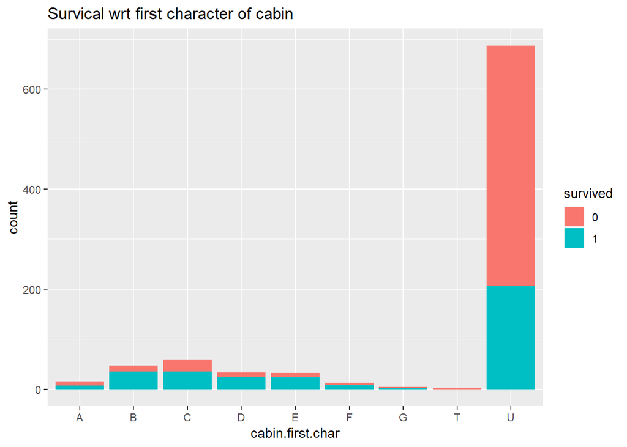

```r
# First high level plot
# x-axis cabin.first.char is a factor so bar plot

ggplot(data.combined[1:891,], aes(x = cabin.first.char, fill = survived)) +
  geom_bar() +
  ggtitle("Survical wrt first character of cabin")
```

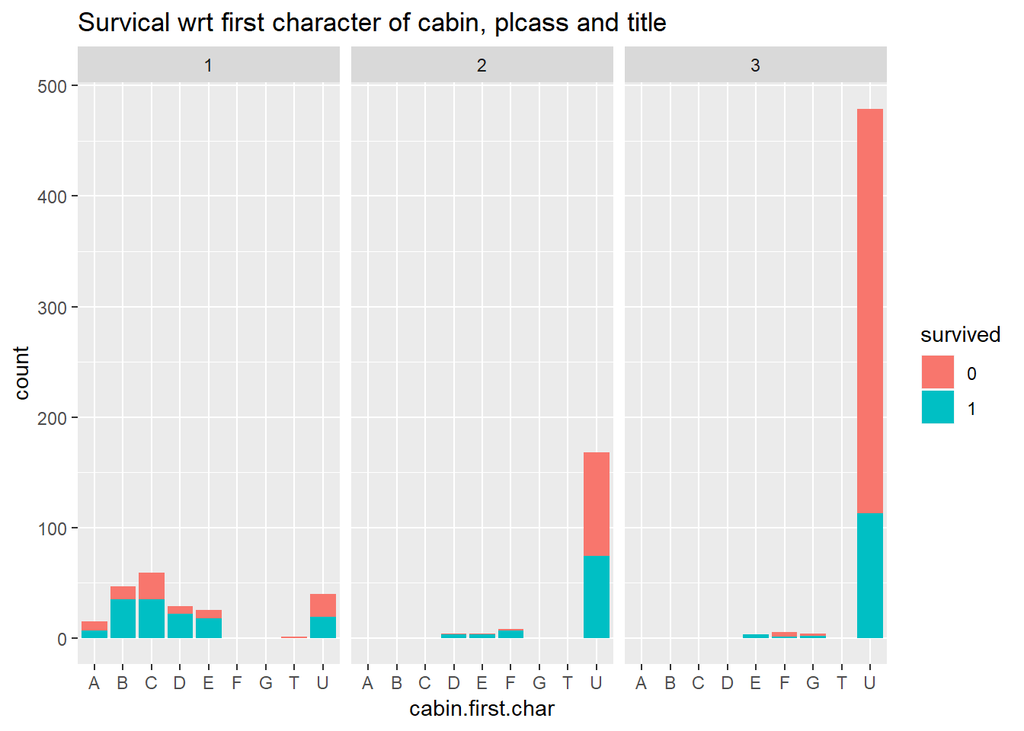

```r
ggplot(data.combined[1:891,], aes(x = cabin.first.char, fill = survived)) +
  geom_bar() +
  facet_wrap(~pclass) +
  ggtitle("Survical wrt first character of cabin, plcass and title")
```

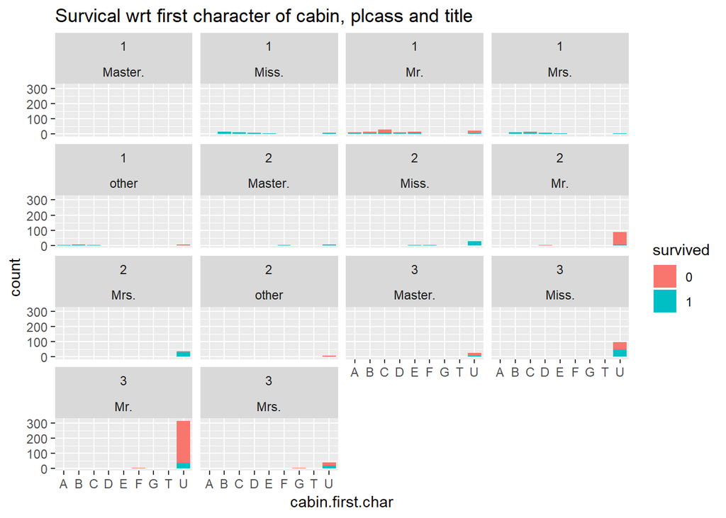

```r
# Does this feature improve upon pclass + title?
ggplot(data.combined[1:891,], aes(x = cabin.first.char, fill = survived)) +
  geom_bar() +
  facet_wrap(~pclass+title) +
  ggtitle("Survical wrt first character of cabin, plcass and title")
```

```r
# What about folks with multiple cabins?
data.combined = data.combined %>% mutate(cabin.multiple = ifelse(
  str_detect(cabin," "), "Y", "N"))


head(data.combined$cabin.multiple)
```

```
## [1] "N" "N" "N" "N" "N" "N"
```

```r
names(data.combined)
```

```
##  [1] "survived"          "pclass"            "name"
##  [4] "sex"               "age"               "sibsp"
##  [7] "parch"             "ticket"            "fare"
## [10] "cabin"             "embarked"          "title"
## [13] "family.size"       "ticket.first.char" "cabin.first.char"
## [16] "cabin.multiple"
```

```r
length(unique(data.combined$cabin.multiple))
```

```
## [1] 2
```

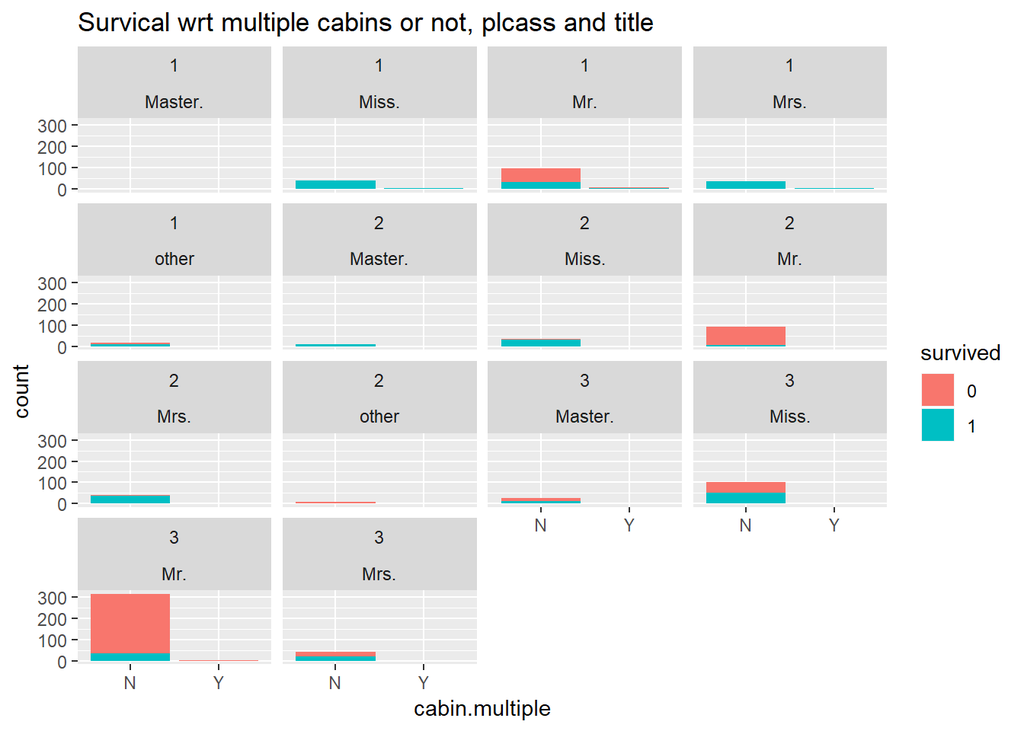

```r
data.combined$cabin.multiple = as.factor(data.combined$cabin.multiple)

# x-axis cabin.multiple is factor so bar plot, broken by categorical variables
# pclass and title

ggplot(data.combined[1:891,], aes(x = cabin.multiple, fill = survived)) +
  geom_bar() +
  facet_wrap(~pclass + title) +
  ggtitle("Survical wrt multiple cabins or not, plcass and title")
```

## 5.10 Explore embarked feature

```r
str(data.combined$embarked)
```

```
##  chr [1:1309] "S" "C" "S" "S" "S" "Q" "S" "S" "S" "C" "S" "S" "S" "S" ...
```

```r
length(unique(data.combined$embarked))
```

```
## [1] 4
```

```r
table(data.combined$embarked)
```

```
##
##       C   Q   S
##   2 270 123 914
```

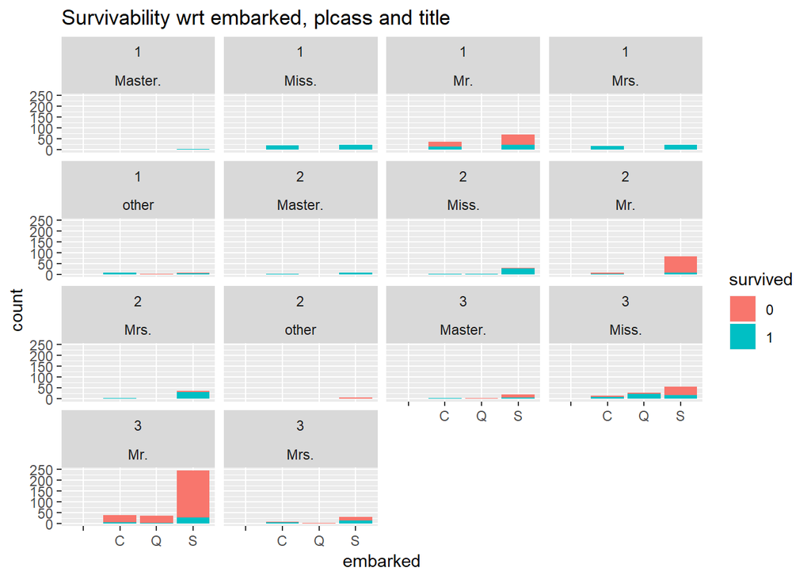

```r
data.combined$embarked = as.factor(data.combined$embarked)

# Does survivability depend on where you got onboard the Titanic?
#x-axis factor variable embarked so bar plot broken by categorical variables
#pclass and title

ggplot(data.combined[1:891,], aes(x = embarked, fill = survived)) +
  geom_bar() +
  facet_wrap(~pclass + title) +
  ggtitle("Survivability wrt embarked, plcass and title")
```

# 6 Visualization

The payoff Investigate the hypothesis that traveling with children might be predictive

```r
# Set up factors
train$survived = as.factor(train$survived)
train$pclass = as.factor(train$pclass)


# Subset passengers traveling with children
tickets.children = train %>%
filter(child.count > 0)
```

## 6.1 Visualize Survival rates for Ticket groups traveling with children

{show survival of children pclass-wise plot bar chart, fill by survived and faceted by Title Give title to your plot Survival Rates for Ticket Groups Traveling with children Lable y-axis as Count of Passengers}

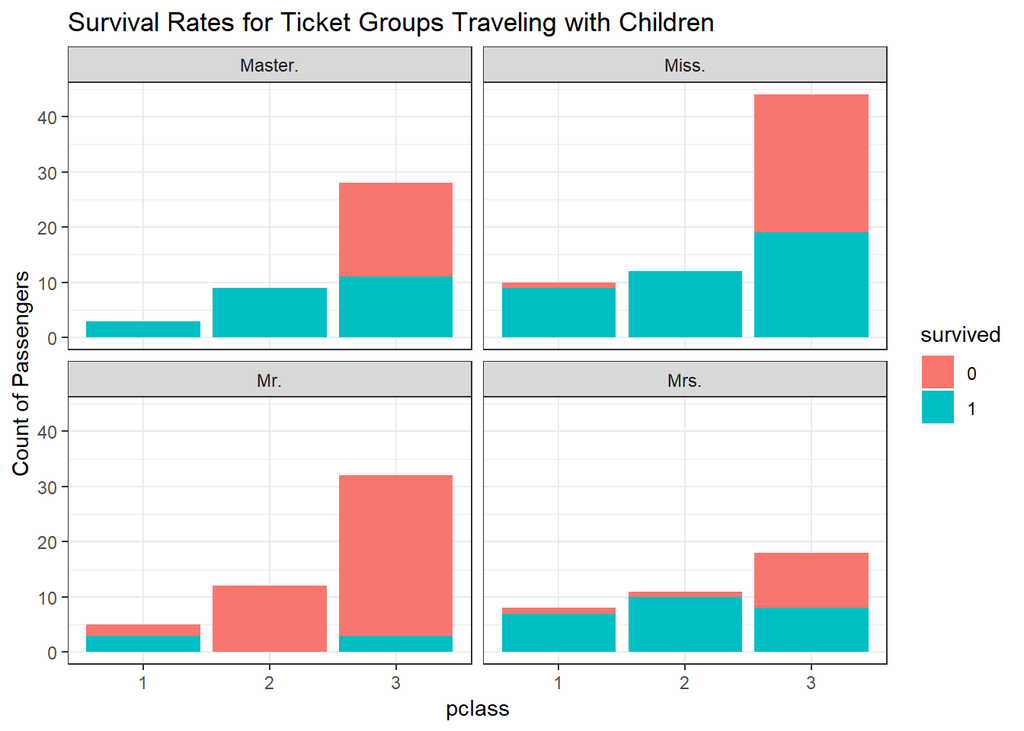

```r
ggplot(tickets.children, aes(x=pclass, fill=survived))+
theme_bw() +
geom_bar() +
facet_wrap(~ title) +
labs(y = "Count of Passengers",
title = "Survival Rates for Ticket Groups Traveling with Children")
```

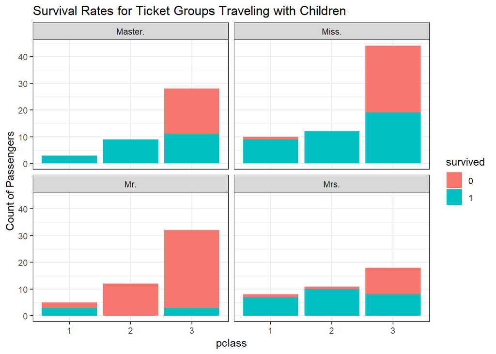

```r
#or

ggplot(tickets.children, aes(x=pclass, fill=survived))+
theme_bw() +
geom_bar() +
facet_wrap(~ title) +
ylab("Count of Passengers") +
ggtitle("Survival Rates for Ticket Groups Traveling with Children")
```

All boys in first, second class survived, in 3rd one-third survivied almost same for Miss, Mrs for comparison, no children Subset passengers traveling with no children

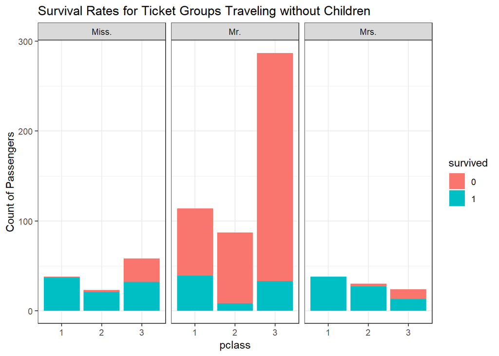

```r
tickets.no.children = train %>%
filter(child.count == 0)

# Visualize
ggplot(tickets.no.children, aes(x=pclass, fill = survived)) +
theme_bw() +
geom_bar() +
facet_wrap(~ title) +
labs(y = "Count of Passengers",
title = "Survival Rates for Ticket Groups Traveling without Children")
```

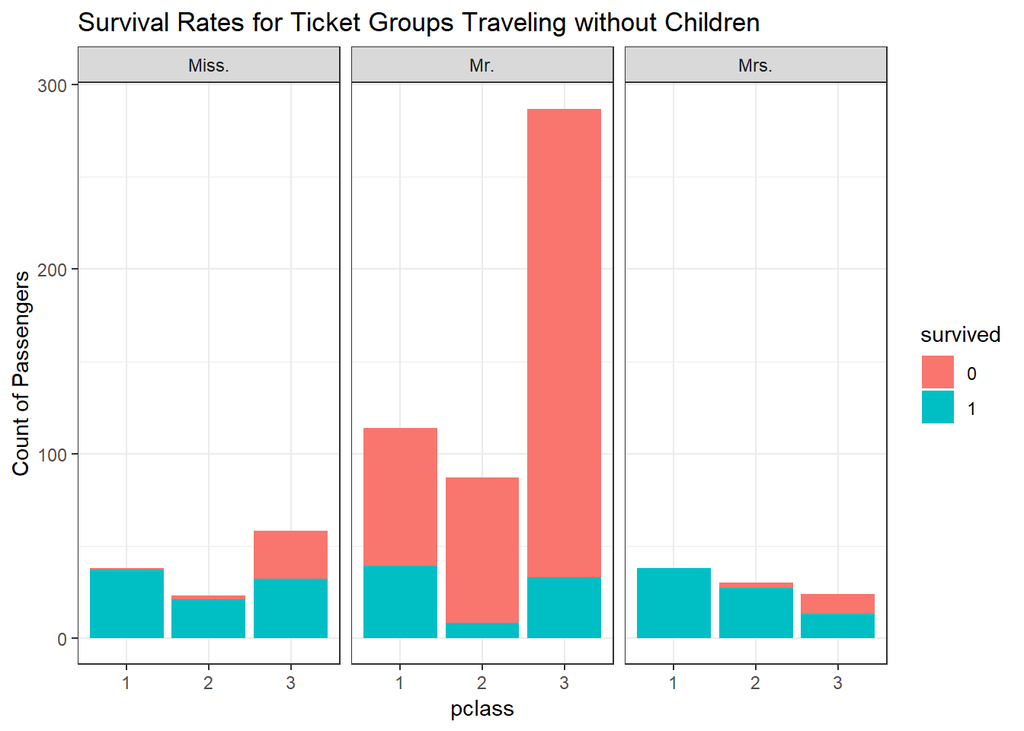

```r
#or

ggplot(tickets.no.children, aes(x=pclass, fill = survived)) +
theme_bw() +
geom_bar() +
facet_wrap(~ title) +
ylab("Count of Passengers")+
ggtitle("Survival Rates for Ticket Groups Traveling without Children")
```

path to save the data.combined dataset with all the new features to be used for exploratory modeling

```r
path
```

```r
saveRDS(data.combined, paste0(path,"/RdsObjects/data.combined.rds"))
```